# Comparing seasonal and latitudinal patterns in thermal adaptation

**Per-SNP seasonal test.** For each SNP, the minor-allele count was modelled with a binomial GLM, count ~ site + x, with each population weighted by its effective number of chromosomes (2cn), as in the *Drosophila* seasonal studies ([Bergland et al. 2014](https://doi.org/10.1371/journal.pgen.1004775); [Machado et al. 2021](https://doi.org/10.7554/eLife.67577)). Two versions of x were fitted: (1) **time**, the collection day of year scaled from 0 (first sampling event at a site) to 1 (last), which rewards change in the same direction through the season at every site; and (2) **temperature**, the mean MUR SST over the generation before each collection (Ganey’s Wharf corrected against station ET5.1), which rewards change that tracks temperature, so that a warming and a cooling step move frequencies in opposite directions. Temperature matters because the season is not a monotonic temperature ramp: water before the early and peak collections was similar (or cooler at peak in the north), and the late collections followed a strong cooling. The null distribution comes from permuting x among each site’s sampling events, enumerating every distinct ordering (time: X 11 and F 23 permutations, as reversing all sites only flips the sign; temperature: X 23 and F 47). The genome-wide test asks whether more SNPs reach a given p value with the real values than with the permuted ones. Results are shown with and without chromosome 6, which carries the likely inversion in clade X (Section 3.2). Clade S has a single seasonal site (MD) with two samples, so it has no permutation null and is not shown.

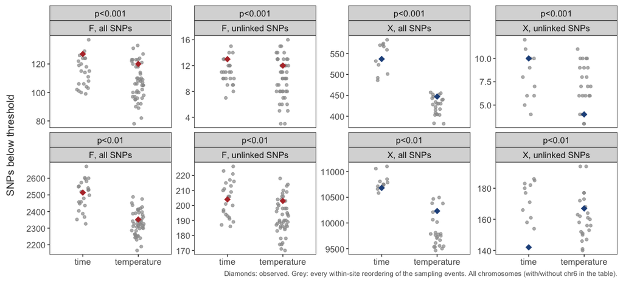

```r
glm_files <- c(Sys.glob(cx("results", "13_seasonal", "*.perm.tsv")),
               Sys.glob(cx("results", "13_seasonal", "temp", "*.perm.tsv")))
if (length(glm_files) == 0) {
  cat("Seasonal GLM results are not in this export yet.")
} else {
  glm_perm <- map_dfr(glm_files, function(f) {
    read_tsv(f, show_col_types = FALSE) %>%
      mutate(clade = str_split_1(basename(f), "\\.")[1], snps_used = str_split_1(basename(f), "\\.")[2],
             model = if_else(basename(dirname(f)) == "temp", "temperature", "time"))
  }) %>%
    filter(clade %in% c("X", "F")) %>%
    mutate(snp_set = if_else(snp_set == "all", "all chr.", "no chr6"),
           model = factor(model, levels = c("time", "temperature")),
           panel = paste0(clade, ", ", snps_used, " SNPs"),
           clade = factor(clade, levels = tonsa_clades)) %>%
    pivot_longer(starts_with("n_p<"), names_to = "threshold", values_to = "n_snps") %>%
    mutate(threshold = sub("n_", "", threshold), observed = perm == 0)

  glm_perm %>%
    filter(threshold %in% c("p<0.01", "p<0.001"), snp_set == "all chr.") %>%
    ggplot(aes(x = model, y = n_snps)) +
    geom_point(data = ~ filter(.x, !observed), colour = "grey60", alpha = 0.7,
               position = position_jitter(width = 0.12, height = 0, seed = 1)) +
    geom_point(data = ~ filter(.x, observed), aes(colour = clade), size = 3.5, shape = 18) +
    facet_wrap(threshold ~ panel, scales = "free_y", nrow = 2) +
    scale_colour_manual(values = clade_cols[tonsa_clades], guide = "none") +
    labs(x = NULL, y = "SNPs below threshold",
         caption = "Diamonds: observed. Grey: every within-site reordering of the sampling events. All chromosomes (with/without chr6 in the table).") +
    theme_matt_facets(base_size = 11)
}
```

```r
if (length(glm_files) > 0) {
  glm_perm %>%
    group_by(clade, snps_used, model, snp_set, threshold) %>%
    summarise(obs = n_snps[observed], perm_mean = mean(n_snps[!observed]),
              perm_max = max(n_snps[!observed]),
              rank = sum(n_snps[!observed] >= n_snps[observed]) + 1, label_sets = n(), .groups = "drop") %>%
    mutate(rank = paste0(rank, " / ", label_sets)) %>%
    select(-label_sets) %>%
    arrange(clade, snps_used, model, snp_set, threshold) %>%
    knitr::kable(digits = 1, col.names = c("Clade", "SNPs", "Model", "Chromosomes", "Threshold", "Observed",
                                          "Permutation mean", "Permutation max", "Rank of observed"),
                 caption = "Per-SNP seasonal GLM: SNPs below each p threshold with the real seasons vs all within-site permutations (rank 1 = more than every permutation).")
}
```

Per-SNP seasonal GLM: SNPs below each p threshold with the real seasons vs all within-site permutations (rank 1 = more than every permutation).

| Clade | SNPs | Model | Chromosomes | Threshold | Observed | Permutation mean | Permutation max | Rank of observed |
| --- | --- | --- | --- | --- | --- | --- | --- | --- |
| X | all | time | all chr. | p<0.0001 | 17 | 19.5 | 28 | 11 / 12 |
| X | all | time | all chr. | p<0.001 | 537 | 541.6 | 583 | 7 / 12 |
| X | all | time | all chr. | p<0.01 | 10682 | 10798.4 | 11100 | 10 / 12 |
| X | all | time | no chr6 | p<0.0001 | 16 | 18.6 | 24 | 11 / 12 |
| X | all | time | no chr6 | p<0.001 | 496 | 507.7 | 540 | 9 / 12 |
| X | all | time | no chr6 | p<0.01 | 10010 | 10164.2 | 10409 | 11 / 12 |
| X | all | temperature | all chr. | p<0.0001 | 11 | 11.9 | 17 | 15 / 24 |
| X | all | temperature | all chr. | p<0.001 | 447 | 425.2 | 457 | 6 / 24 |
| X | all | temperature | all chr. | p<0.01 | 10233 | 9849.9 | 10496 | 5 / 24 |
| X | all | temperature | no chr6 | p<0.0001 | 11 | 11.4 | 16 | 15 / 24 |
| X | all | temperature | no chr6 | p<0.001 | 423 | 399.8 | 434 | 5 / 24 |
| X | all | temperature | no chr6 | p<0.01 | 9615 | 9263.7 | 9844 | 5 / 24 |
| X | unlinked | time | all chr. | p<0.0001 | 0 | 0.2 | 1 | 12 / 12 |
| X | unlinked | time | all chr. | p<0.001 | 10 | 8.0 | 12 | 5 / 12 |
| X | unlinked | time | all chr. | p<0.01 | 142 | 173.0 | 186 | 12 / 12 |
| X | unlinked | time | no chr6 | p<0.0001 | 0 | 0.2 | 1 | 12 / 12 |
| X | unlinked | time | no chr6 | p<0.001 | 10 | 7.3 | 11 | 2 / 12 |
| X | unlinked | time | no chr6 | p<0.01 | 134 | 161.2 | 172 | 12 / 12 |
| X | unlinked | temperature | all chr. | p<0.0001 | 0 | 0.2 | 1 | 24 / 24 |
| X | unlinked | temperature | all chr. | p<0.001 | 4 | 7.1 | 11 | 22 / 24 |
| X | unlinked | temperature | all chr. | p<0.01 | 167 | 161.5 | 194 | 8 / 24 |
| X | unlinked | temperature | no chr6 | p<0.0001 | 0 | 0.2 | 1 | 24 / 24 |
| X | unlinked | temperature | no chr6 | p<0.001 | 4 | 6.4 | 10 | 22 / 24 |
| X | unlinked | temperature | no chr6 | p<0.01 | 158 | 150.7 | 181 | 9 / 24 |
| F | all | time | all chr. | p<0.0001 | 2 | 3.3 | 9 | 19 / 24 |
| F | all | time | all chr. | p<0.001 | 127 | 114.2 | 137 | 3 / 24 |
| F | all | time | all chr. | p<0.01 | 2514 | 2498.2 | 2671 | 13 / 24 |
| F | all | time | no chr6 | p<0.0001 | 2 | 3.0 | 9 | 19 / 24 |
| F | all | time | no chr6 | p<0.001 | 116 | 103.2 | 122 | 3 / 24 |
| F | all | time | no chr6 | p<0.01 | 2323 | 2286.2 | 2467 | 8 / 24 |
| F | all | temperature | all chr. | p<0.0001 | 5 | 3.8 | 8 | 16 / 48 |
| F | all | temperature | all chr. | p<0.001 | 120 | 107.5 | 133 | 13 / 48 |
| F | all | temperature | all chr. | p<0.01 | 2352 | 2331.4 | 2488 | 17 / 48 |
| F | all | temperature | no chr6 | p<0.0001 | 3 | 3.6 | 7 | 35 / 48 |
| F | all | temperature | no chr6 | p<0.001 | 110 | 97.1 | 122 | 11 / 48 |
| F | all | temperature | no chr6 | p<0.01 | 2162 | 2129.3 | 2305 | 16 / 48 |
| F | unlinked | time | all chr. | p<0.0001 | 0 | 0.1 | 1 | 24 / 24 |
| F | unlinked | time | all chr. | p<0.001 | 13 | 11.0 | 15 | 6 / 24 |
| F | unlinked | time | all chr. | p<0.01 | 204 | 204.3 | 226 | 13 / 24 |
| F | unlinked | time | no chr6 | p<0.0001 | 0 | 0.1 | 1 | 24 / 24 |
| F | unlinked | time | no chr6 | p<0.001 | 12 | 9.9 | 14 | 6 / 24 |
| F | unlinked | time | no chr6 | p<0.01 | 193 | 186.2 | 211 | 8 / 24 |
| F | unlinked | temperature | all chr. | p<0.0001 | 0 | 0.1 | 1 | 48 / 48 |
| F | unlinked | temperature | all chr. | p<0.001 | 12 | 10.1 | 16 | 20 / 48 |
| F | unlinked | temperature | all chr. | p<0.01 | 203 | 192.9 | 218 | 13 / 48 |
| F | unlinked | temperature | no chr6 | p<0.0001 | 0 | 0.1 | 1 | 48 / 48 |
| F | unlinked | temperature | no chr6 | p<0.001 | 11 | 9.1 | 16 | 17 / 48 |
| F | unlinked | temperature | no chr6 | p<0.01 | 189 | 176.2 | 206 | 10 / 48 |

There is no genome-wide excess of seasonal SNPs in either clade, with either model. With the real seasons, X and F have about as many low-p SNPs as the permuted orderings, at every threshold, on both the unlinked and the full SNP sets. Modelling temperature instead of time does not change this: the closest to a signal is clade X on all SNPs (rank 5–6 of 24 at p < 0.01 and p < 0.001, i.e. p ≈ 0.2–0.25), which is not significant and does not hold on the unlinked set. Removing chromosome 6 changes nothing, so the X inversion is not driving or masking a seasonal signal. The genomic-control λ is close to 1 (X ≈ 1.1, F ≈ 1.0) for the observed and permuted values alike, so the calibrated binomial weights describe the sampling variance well. Together with the uncorrelated early→peak changes across X sites, this means that any seasonal selection in these populations acts on too few loci, or is too weak, to show up genome-wide with 3–4 seasonal sites per clade, whether it is modelled as a seasonal trend or as a response to temperature. Individual SNPs with the smallest p values are listed in `results/13_seasonal/*.top.tsv` and `results/13_seasonal/temp/*.top.tsv` but are not more numerous than expected by chance, so none can be called a seasonal candidate on its own. The permutation null is coarse (time: 12 and 24 orderings; temperature: 24 and 48), which limits the smallest attainable rank-based p value to 1/12–1/48.

### Spatial vs. seasonal genetic variation

How much do allele frequencies differ between sites compared with between seasons at the same site? Within each clade, the variance of population allele frequencies at the unlinked SNPs was split into a between-site component and a between-season (within-site) component, after subtracting the calibrated sampling noise (1/(2cn) per population, from the split-half calibration). Both are expressed relative to p̄(1 − p̄), like F<sub>ST</sub>, summed over SNPs (ratio of sums), with 95% intervals from a delete-one-chromosome jackknife. The between-site component reflects long-term history and spatial selection; the seasonal component reflects drift and selection over a single season (3–20 generations).

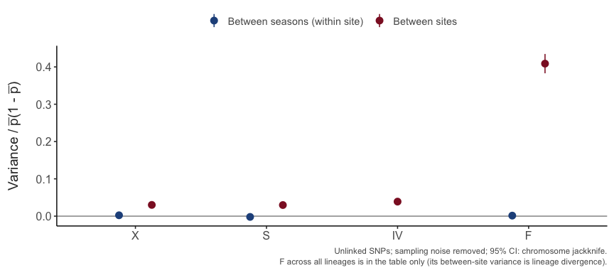

```r
if (length(freq_files) == 0 || is.null(split_half)) {
  cat("Allele-frequency tables or the split-half calibration are not in this export yet.")
} else {
  # population sets (clade.prefix = which frequency table): F-N = F populations at MD and GW;
  # F as a whole spans three lineages (its between-site component includes lineage divergence)
  vp_sets <- list(X = c("X", NA), S = c("S", NA), IV = c("IV", NA), F = c("F", NA))
  vp_freq <- map_dfr(names(vp_sets), function(nm) {
    cl <- vp_sets[[nm]][1]; site_pat <- vp_sets[[nm]][2]
    f <- cx("results", "09_stage34", paste0(cl, ".freqs.unlinked.tsv.gz"))
    if (!file.exists(f)) return(NULL)
    m <- read_tsv(f, show_col_types = FALSE, col_types = cols(chrom = "c"))
    pops <- sub("^freq_", "", grep("^freq_", names(m), value = TRUE))
    site <- str_split_i(pops, "__", 2)
    if (!is.na(site_pat)) { keep <- str_detect(site, paste0("^(", site_pat, ")$")); pops <- pops[keep]; site <- site[keep] }
    P <- as.matrix(m[paste0("freq_", pops)]); N <- as.matrix(m[paste0("nind_", pops)])
    cvec <- unname(c_of[pops]); cvec[is.na(cvec)] <- median(c_of)
    ok <- rowSums(is.na(P)) == 0 & rowSums(N < 5, na.rm = TRUE) == 0 & rowSums(is.na(N)) == 0
    pbar <- rowMeans(P); ok <- ok & pbar >= 0.05 & pbar <= 0.95
    P <- P[ok, , drop = FALSE]; N <- N[ok, , drop = FALSE]; pbar <- pbar[ok]; chrom <- m$chrom[ok]
    # sampling variance of each population's frequency, from its own frequency:
    # E[p(1-p)] = p(1-p)(1 - 1/n_eff), so p(1-p) / (n_eff - 1) is unbiased; n_eff = 2cn chromosomes
    neff <- 2 * sweep(N, 2, cvec, "*")
    s2 <- P * (1 - P) / pmax(neff - 1, 1)
    sites <- unique(site); I <- length(sites); k <- table(site)[sites]
    # within-site (seasonal) component
    W <- 0; EW <- 0
    msite <- sapply(sites, function(s) rowMeans(P[, site == s, drop = FALSE]))
    if (!is.matrix(msite)) msite <- matrix(msite, ncol = I)
    s2bar <- sapply(sites, function(s) rowMeans(s2[, site == s, drop = FALSE]))
    if (!is.matrix(s2bar)) s2bar <- matrix(s2bar, ncol = I)
    for (j in seq_along(sites)) {
      cols <- which(site == sites[j])
      W <- W + rowSums((P[, cols, drop = FALSE] - msite[, j])^2)
      EW <- EW + rowSums(s2[, cols, drop = FALSE]) * (1 - 1 / k[[j]])
    }
    df_w <- sum(k - 1)
    sig_season <- if (df_w > 0) (W - EW) / df_w else rep(NA_real_, length(pbar))
    # between-site component
    sig_site <- if (I > 1) {
      B <- rowSums((msite - rowMeans(msite))^2)
      adj <- rowSums(sweep(s2bar, 2, as.numeric(k), "/")) + (if (df_w > 0) sig_season else 0) * sum(1 / k)
      (B - (1 - 1 / I) * adj) / (I - 1)
    } else rep(NA_real_, length(pbar))
    het <- pbar * (1 - pbar)
    est <- function(sel) c(site = sum(sig_site[sel]) / sum(het[sel]), season = sum(sig_season[sel]) / sum(het[sel]))
    full <- est(rep(TRUE, length(pbar)))
    jk <- sapply(unique(chrom), function(ch) est(chrom != ch)); g <- ncol(jk)
    se <- sqrt((g - 1) / g * rowSums((jk - rowMeans(jk))^2))
    tibble(group = nm, component = c("Between sites", "Between seasons (within site)"),
           value = unname(full), lo = unname(full - 1.96 * se), hi = unname(full + 1.96 * se),
           sites = I, populations = length(pops), seasonal_sites = sum(k > 1), snps = length(pbar))
  }) %>%
    mutate(group = factor(group, levels = names(vp_sets)))

  ggplot(filter(vp_freq, !is.na(value), group != "F (all lineages)"), aes(x = group, y = value, colour = component)) +
    geom_hline(yintercept = 0, colour = "grey60") +
    geom_pointrange(aes(ymin = lo, ymax = hi), position = position_dodge(width = 0.5), size = 0.6) +
    scale_colour_manual(values = c(`Between sites` = unname(lat_gradient["MR"]),
                                   `Between seasons (within site)` = unname(lat_gradient["X"])), name = NULL) +
    labs(x = NULL, y = expression("Variance / " * bar(p) * "(1 - " * bar(p) * ")"),
         caption = "Unlinked SNPs; sampling noise removed; 95% CI: chromosome jackknife.\nF across all lineages is in the table only (its between-site variance is lineage divergence).") +
    theme_matt(base_size = 12) +
    theme(legend.position = "top")
}
```

```r
if (exists("vp_freq")) {
  vp_freq %>%
    mutate(value = if_else(is.na(value), "–", sprintf("%.4f (%.4f, %.4f)", value, lo, hi))) %>%
    select(group, component, value, sites, seasonal_sites, populations, snps) %>%
    pivot_wider(names_from = component, values_from = value) %>%
    mutate(`Site : season ratio` = map2_chr(group, sites, function(g, s) {
      v <- filter(vp_freq, group == g)
      se <- v[v$component == "Between seasons (within site)", ]
      if (any(is.na(v$value)) || se$lo <= 0) "–" else
        sprintf("%.0f", v$value[v$component == "Between sites"] / se$value)
    })) %>%
    knitr::kable(col.names = c("Group", "Sites", "Sites with ≥ 2 seasons", "Populations", "SNPs",
                               "Between sites", "Between seasons", "Site : season ratio"),
                 caption = "Allele-frequency variance between sites and between seasons within sites, relative to p̄(1 − p̄), after removing sampling noise (95% CI). Ratio shown only where the seasonal component is clearly above zero.")
}
```

Allele-frequency variance between sites and between seasons within sites, relative to p̄(1 − p̄), after removing sampling noise (95% CI). Ratio shown only where the seasonal component is clearly above zero.

| Group | Sites | Sites with ≥ 2 seasons | Populations | SNPs | Between sites | Between seasons | Site : season ratio |
| --- | --- | --- | --- | --- | --- | --- | --- |
| X | 3 | 3 | 7 | 38543 | 0.0301 (0.0269, 0.0333) | 0.0023 (0.0012, 0.0034) | 13 |
| S | 3 | 1 | 4 | 16025 | 0.0298 (0.0231, 0.0365) | -0.0020 (-0.0044, 0.0004) | – |
| IV | 2 | 0 | 2 | 28489 | 0.0390 (0.0335, 0.0445) | – | – |
| F | 4 | 4 | 9 | 24494 | 0.4088 (0.3829, 0.4347) | 0.0014 (0.0006, 0.0022) | 289 |

### Does space substitute for time? Concordance of temperature responses

If the alleles that are more common at warmer sites are favoured by warm conditions, they should also rise after warm periods and fall after cool ones within sites. For every SNP, two temperature slopes were estimated with the same binomial GLM and calibrated weights as above: a **spatial** slope (frequency against each site’s long-term MUR SST, with a site’s seasonal samples pooled) and a **seasonal** slope (the temperature model above: frequency against site + temperature before collection). Their agreement across the genome was measured as the correlation of the two z-scores, and, among the 1% and 5% of SNPs with the strongest spatial slopes, as the fraction whose seasonal slope has the same sign (0.5 = no agreement). The null keeps the spatial slopes and permutes temperatures among each site’s sampling events (as in the seasonal test); a second, smaller null permutes site temperatures among sites. This is the genomic counterpart of the within- vs between-site comparison for CTmax (Section 4) and follows the seasonal–clinal comparison of [Machado et al. (2021)](https://doi.org/10.7554/eLife.67577).

Clade X (ME, TK, RW; one lineage, three seasonal sites) is the main test. In clade F the warm sites (MR, FH) and the cool sites (MD, GW) belong to different lineages, so its spatial slopes mostly reflect lineage differences, not temperature; F is shown for completeness but not interpreted. Clade S has one seasonal site, so its seasonal null has a single alternative ordering.

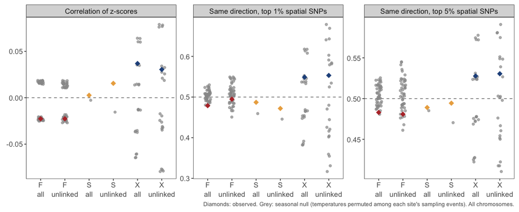

```r
conc_files <- Sys.glob(cx("results", "14_concordance", "*.perm.tsv"))
if (length(conc_files) == 0) {
  cat("Concordance results are not in this export yet.")
} else {
  conc <- map_dfr(conc_files, function(f) {
    read_tsv(f, show_col_types = FALSE) %>%
      mutate(clade = str_split_1(basename(f), "\\.")[1], snps_used = str_split_1(basename(f), "\\.")[2])
  }) %>%
    mutate(snp_set = if_else(snp_set == "all", "all chr.", "no chr6"),
           clade = factor(clade, levels = tonsa_clades),
           observed = null == "seasonal" & perm == 0)

  conc %>%
    filter(snp_set == "all chr.", null == "seasonal") %>%
    select(clade, snps_used, observed, r, conc_top1, conc_top5) %>%
    pivot_longer(c(r, conc_top1, conc_top5), names_to = "statistic", values_to = "value") %>%
    mutate(statistic = recode(statistic, r = "Correlation of z-scores",
                              conc_top1 = "Same direction, top 1% spatial SNPs",
                              conc_top5 = "Same direction, top 5% spatial SNPs"),
           x = paste(clade, snps_used, sep = "\n")) %>%
    ggplot(aes(x = x, y = value)) +
    geom_hline(data = tibble(statistic = c("Correlation of z-scores", "Same direction, top 1% spatial SNPs",
                                           "Same direction, top 5% spatial SNPs"), h = c(0, 0.5, 0.5)),
               aes(yintercept = h), colour = "grey50", linetype = "dashed") +
    geom_point(data = ~ filter(.x, !observed), colour = "grey60", alpha = 0.7,
               position = position_jitter(width = 0.12, height = 0, seed = 1)) +
    geom_point(data = ~ filter(.x, observed), aes(colour = str_sub(x, 1, 1)), size = 3.5, shape = 18) +
    facet_wrap(~ statistic, scales = "free_y") +
    scale_colour_manual(values = setNames(clade_cols[c("F", "S", "X")], c("F", "S", "X")), guide = "none") +
    labs(x = NULL, y = NULL,
         caption = "Diamonds: observed. Grey: seasonal null (temperatures permuted among each site's sampling events). All chromosomes.") +
    theme_matt_facets(base_size = 11)
}
```

```r
if (length(conc_files) > 0) {
  conc %>%
    filter(null == "seasonal") %>%
    group_by(clade, snps_used, snp_set) %>%
    summarise(snps = snps[observed],
              r_obs = r[observed], r_rank = sum(r[!observed] >= r[observed]) + 1,
              top1_obs = conc_top1[observed], top1_rank = sum(conc_top1[!observed] >= conc_top1[observed]) + 1,
              top5_obs = conc_top5[observed], top5_rank = sum(conc_top5[!observed] >= conc_top5[observed]) + 1,
              sets = n(), .groups = "drop") %>%
    mutate(across(ends_with("_rank"), ~ paste0(.x, " / ", sets))) %>%
    select(-sets) %>%
    arrange(clade, snps_used, snp_set) %>%
    knitr::kable(digits = 3,
                 col.names = c("Clade", "SNPs", "Chromosomes", "SNPs tested", "r", "Rank",
                               "Top 1% same sign", "Rank", "Top 5% same sign", "Rank"),
                 caption = "Concordance of spatial and seasonal temperature slopes. Rank = position of the observed value among all seasonal-null orderings (1 = higher than every permutation).")
}
```

Concordance of spatial and seasonal temperature slopes. Rank = position of the observed value among all seasonal-null orderings (1 = higher than every permutation).

| Clade | SNPs | Chromosomes | SNPs tested | r | Rank | Top 1% same sign | Rank | Top 5% same sign | Rank |
| --- | --- | --- | --- | --- | --- | --- | --- | --- | --- |
| X | all | all chr. | 2056496 | 0.037 | 5 / 24 | 0.549 | 6 / 24 | 0.528 | 6 / 24 |
| X | all | no chr6 | 1918570 | 0.035 | 8 / 24 | 0.548 | 6 / 24 | 0.527 | 8 / 24 |
| X | unlinked | all chr. | 42357 | 0.030 | 8 / 24 | 0.553 | 10 / 24 | 0.530 | 9 / 24 |
| X | unlinked | no chr6 | 39302 | 0.030 | 9 / 24 | 0.555 | 10 / 24 | 0.534 | 9 / 24 |
| F | all | all chr. | 470321 | -0.023 | 36 / 48 | 0.479 | 48 / 48 | 0.483 | 47 / 48 |
| F | all | no chr6 | 437032 | -0.022 | 30 / 48 | 0.484 | 48 / 48 | 0.487 | 45 / 48 |
| F | unlinked | all chr. | 38608 | -0.023 | 36 / 48 | 0.495 | 34 / 48 | 0.481 | 43 / 48 |
| F | unlinked | no chr6 | 35928 | -0.023 | 34 / 48 | 0.493 | 33 / 48 | 0.486 | 39 / 48 |
| S | all | all chr. | 273722 | 0.003 | 1 / 2 | 0.487 | 1 / 2 | 0.489 | 1 / 2 |
| S | all | no chr6 | 254773 | 0.002 | 1 / 2 | 0.492 | 1 / 2 | 0.491 | 1 / 2 |
| S | unlinked | all chr. | 26743 | 0.016 | 1 / 2 | 0.472 | 1 / 2 | 0.494 | 1 / 2 |
| S | unlinked | no chr6 | 25076 | 0.016 | 1 / 2 | 0.472 | 1 / 2 | 0.494 | 1 / 2 |

### Power of the genomic tests

How much seasonal selection could these tests have detected? Selection was injected into the observed allele frequencies (unlinked SNPs) and each test rerun exactly as above (cluster target `power`; `results/18_power/`), so drift, sampling noise and the sampling design are those of the real data.

- **Seasonal GLM and temporal Fc:** a random fraction of SNPs (0.1–10%) had their logit frequency shifted by δ between each site’s first and last sample, in the same direction at every site. δ is shown below as the change in allele frequency for an allele starting at 50%, and as selection per generation using the generations between each clade’s first and last samples. A replicate counts as detected when the observed number of SNPs with p < 10⁻³ exceeds every within-site permutation (the smallest attainable p is 1/12 for X and 1/24 for F), or, for Fc, when the added excess exceeds the observed excess plus 1.96 SE (inverse-variance pooled over each site’s first → last pair).
- **Concordance:** the most temperature-associated SNPs across sites (top 1–100% by spatial z) were given a seasonal response equal to a fraction λ of their spatial slope; detection = ranking above every seasonal permutation.

With strong injected responses (λ ≥ 0.5) the sign-agreement statistic saturates at 1 in the permutations too, so those cells can show as undetected in F; the relevant region is the weak-response end, where both clades detect responses of a tenth (X) or a twentieth (F) of the spatial slope.

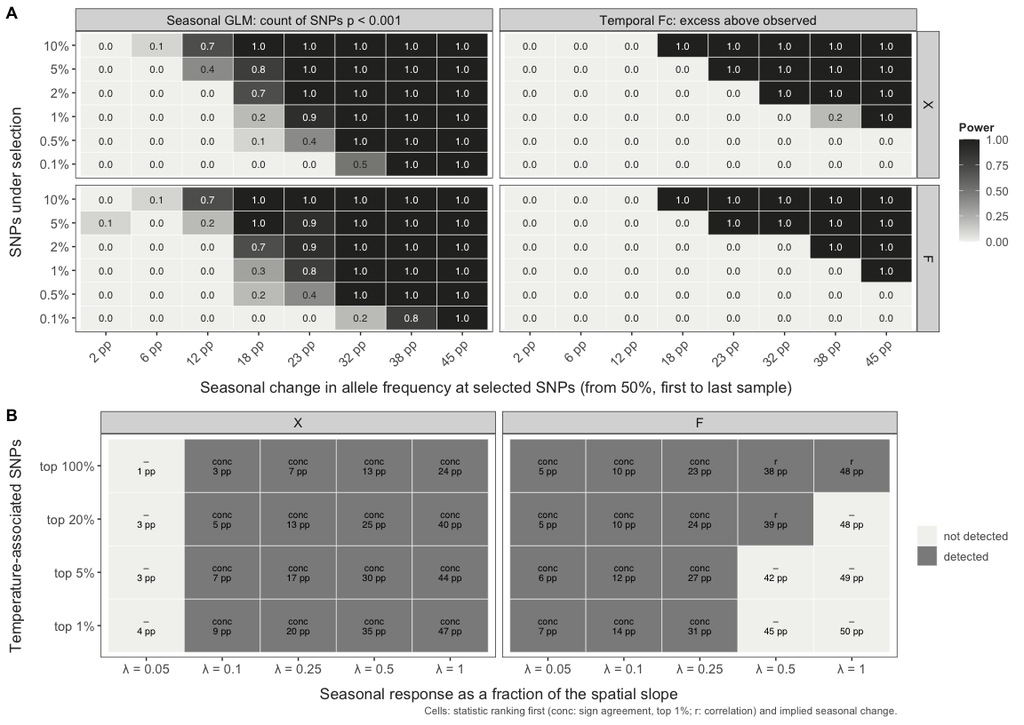

```r
pw_dir <- cx("results", "18_power")
pw_clades <- intersect(c("X", "F"), sub("\\.seasonal_glm\\.tsv$", "", dir(pw_dir, "seasonal_glm")))
have_pw <- length(pw_clades) > 0 && exists("temporal")
if (!have_pw) {
  cat("Power results (results/18_power/) are not in this export yet.")
} else {
  pts <- function(d) 100 * (plogis(d) - 0.5)                         # pp change from 50%
  gen_first_last <- temporal %>% group_by(clade = as.character(clade), site) %>%
    summarise(gens = max(gens), .groups = "drop") %>% group_by(clade) %>% summarise(gens = mean(gens))
  glm_pw <- map_dfr(pw_clades, ~ read_tsv(file.path(pw_dir, paste0(.x, ".seasonal_glm.tsv")), col_types = cols(clade = "c", .default = col_guess()))) %>%
    group_by(clade, delta, frac) %>% summarise(power = mean(rank == 1), .groups = "drop") %>%
    mutate(test = "Seasonal GLM: count of SNPs p < 0.001")
  obs_pairs <- temporal %>% mutate(clade = as.character(clade)) %>% select(clade, site, from, to, excess, se)
  fc_pw <- map_dfr(pw_clades, ~ read_tsv(file.path(pw_dir, paste0(.x, ".seasonal_fc.tsv")), col_types = cols(clade = "c", site = "c", .default = col_guess()))) %>%
    inner_join(obs_pairs, by = c("clade", "site", "from", "to")) %>%
    mutate(w = 1 / se^2) %>%
    group_by(clade, delta, frac, rep) %>%
    summarise(added = sum(w * added_excess) / sum(w), obs = sum(w * excess) / sum(w), se = 1 / sqrt(sum(w)), .groups = "drop") %>%
    group_by(clade, delta, frac) %>% summarise(power = mean(added > obs + 1.96 * se), .groups = "drop") %>%
    mutate(test = "Temporal Fc: excess above observed")
  pw_long <- bind_rows(glm_pw, fc_pw) %>%
    left_join(gen_first_last, by = "clade") %>%
    mutate(clade = factor(clade, levels = c("X", "F")),
           dlab = factor(sprintf("%.0f pp", pts(delta)), levels = sprintf("%.0f pp", pts(sort(unique(delta))))),
           flab = factor(paste0(100 * frac, "%"), levels = paste0(100 * sort(unique(frac)), "%")))
  p_sea <- ggplot(pw_long, aes(x = dlab, y = flab, fill = power)) +
    geom_tile(colour = "white") +
    geom_text(aes(label = sprintf("%.1f", power), colour = power > 0.5), size = 3) +
    facet_grid(clade ~ test) +
    scale_fill_gradient(low = "#F2F2F0", high = "#2B2B29", limits = c(0, 1), name = "Power") +
    scale_colour_manual(values = c(`TRUE` = "white", `FALSE` = "grey20"), guide = "none") +
    labs(x = "Seasonal change in allele frequency at selected SNPs (from 50%, first to last sample)",
         y = "SNPs under selection") +
    theme_matt_facets(base_size = 11) +
    theme(axis.text.x = element_text(angle = 45, hjust = 1))

  conc_pw <- map_dfr(pw_clades, ~ read_tsv(file.path(pw_dir, paste0(.x, ".concordance.tsv")), col_types = cols(clade = "c", .default = col_guess()))) %>%
    mutate(clade = factor(clade, levels = c("X", "F")),
           detected = pmin(conc_rank, r_rank) == 1,
           lab = sprintf("%s\n%.0f pp", if_else(conc_rank == 1, "conc", if_else(r_rank == 1, "r", "–")), pts(seasonal_logit_change)),
           flab = factor(paste0("top ", 100 * frac, "%"), levels = paste0("top ", 100 * sort(unique(frac)), "%")),
           llab = factor(paste0("λ = ", lambda), levels = paste0("λ = ", sort(unique(lambda)))))
  p_conc <- ggplot(conc_pw, aes(x = llab, y = flab, fill = detected)) +
    geom_tile(colour = "white") +
    geom_text(aes(label = lab), size = 2.8, lineheight = 0.85) +
    facet_wrap(~ clade, nrow = 1) +
    scale_fill_manual(values = c(`TRUE` = "grey55", `FALSE` = "#F2F2F0"), labels = c(`TRUE` = "detected", `FALSE` = "not detected"), name = NULL) +
    labs(x = "Seasonal response as a fraction of the spatial slope", y = "Temperature-associated SNPs",
         caption = "Cells: statistic ranking first (conc: sign agreement, top 1%; r: correlation) and implied seasonal change.") +
    theme_matt_facets(base_size = 11)
  ggarrange(p_sea, p_conc, ncol = 1, heights = c(1.25, 1), labels = c("A", "B"))
}
```

```r
if (have_pw) {
  thr_tab <- glm_pw %>% filter(power >= 0.8) %>% group_by(clade, frac) %>% summarise(delta = min(delta), .groups = "drop") %>%
    mutate(test = "Seasonal GLM") %>%
    bind_rows(fc_pw %>% filter(power >= 0.8) %>% group_by(clade, frac) %>% summarise(delta = min(delta), .groups = "drop") %>%
                mutate(test = "Temporal Fc")) %>%
    left_join(gen_first_last, by = "clade") %>%
    transmute(Test = test, Clade = clade, `SNPs under selection` = paste0(100 * frac, "%"),
              `Smallest change detected (pp from 50%)` = round(pts(delta)),
              `Selection per generation (s)` = signif(delta / gens, 2)) %>%
    arrange(Test, Clade, parse_number(`SNPs under selection`))
  knitr::kable(thr_tab, caption = "Smallest injected seasonal change detected with ≥ 80% power, by test, clade and fraction of SNPs under selection (combinations not listed were not detected at any tested strength). s = change in logit frequency divided by the mean generations between each site's first and last sample.")
}
```

Smallest injected seasonal change detected with ≥ 80% power, by test, clade and fraction of SNPs under selection (combinations not listed were not detected at any tested strength). s = change in logit frequency divided by the mean generations between each site’s first and last sample.

| Test | Clade | SNPs under selection | Smallest change detected (pp from 50%) | Selection per generation (s) |
| --- | --- | --- | --- | --- |
| Seasonal GLM | F | 0.1% | 38 | 0.110 |
| Seasonal GLM | F | 0.5% | 32 | 0.083 |
| Seasonal GLM | F | 1% | 23 | 0.056 |
| Seasonal GLM | F | 2% | 23 | 0.056 |
| Seasonal GLM | F | 5% | 18 | 0.042 |
| Seasonal GLM | F | 10% | 18 | 0.042 |
| Seasonal GLM | X | 0.1% | 38 | 0.350 |
| Seasonal GLM | X | 0.5% | 32 | 0.260 |
| Seasonal GLM | X | 1% | 23 | 0.180 |
| Seasonal GLM | X | 2% | 23 | 0.180 |
| Seasonal GLM | X | 5% | 18 | 0.130 |
| Seasonal GLM | X | 10% | 18 | 0.130 |
| Temporal Fc | F | 1% | 45 | 0.170 |
| Temporal Fc | F | 2% | 38 | 0.110 |
| Temporal Fc | F | 5% | 23 | 0.056 |
| Temporal Fc | F | 10% | 18 | 0.042 |
| Temporal Fc | X | 1% | 45 | 0.530 |
| Temporal Fc | X | 2% | 32 | 0.260 |
| Temporal Fc | X | 5% | 23 | 0.180 |
| Temporal Fc | X | 10% | 18 | 0.130 |

In clade X the spatial and seasonal responses point weakly in the same direction: across all SNPs the two slopes are slightly positively correlated (r ≈ 0.04), and among the 1% of SNPs with the strongest spatial slopes about 55% change in the same direction through the season. But the real temperatures rank only 5th–6th of 24 orderings (p ≈ 0.2), 8th–12th on the unlinked set, and the smaller spatial null (6 orderings) cannot go below p ≈ 0.17; removing chromosome 6 changes nothing. So there is no detectable genome-wide concordance between spatial and seasonal temperature responses. Two limits shape this answer. First, the spatial temperature contrast within X is short (7.1–9.9 °C long-term mean across ME, TK and RW), and the spatial slope is mostly ME against the two Gulf of St. Lawrence sites, so it also carries their geographic separation. Second, the null rests on only 24 orderings. A modest true concordance, of the size seen here, could go undetected. Clade F shows the opposite tendency (its observed concordance is the lowest of 48 orderings for the top-1% statistic), but because its spatial contrast is a contrast between lineages (Florida lineages vs F-N) it is not interpreted as a temperature response. Clade S has no usable seasonal null.

In contrast to CTmax, whose between-site slope matches the within-site (acclimation) slope (Section 4), allele frequencies give no evidence that the response to temperature across sites predicts the response through the season. The genomic side of the space-for-time question therefore remains unresolved rather than negative: the data are consistent with no shared response and with a weak one.

## 4. Clade-specific physiological patterns

### CTmax model

To more formally test the relationship between CTmax and collection temperature, we used a linear mixed effects model, structured as `ctmax ~ clade * temp_cent + (1 | site) + (1 | replicate) + (1 | tube)`. This examines the effects of clade and temperature on CTmax, along with clade-specific effects of temperature. Body size is not included, so temperature effects include any effect acting through body size. Collection temperature was centered before model fitting. The model also includes random intercepts for each site, the assay run (replicate) and the tube number (the position of each individual within the water bath during the CTmax assay).

```r
# Both collection temperature and clade ID, along with the interaction, had a significant effect on CTmax. These results are further examined in the clade-specific physiological patterns section.
#
# By extracting the conditional mode for the random effects, we can also examine how thermal limits vary across sites beyond the influence of collection temperatures and body sizes. Shown below are these "population" values (essentially, all else being equal, how would thermal limit vary across populations). We can see that, similar to what's been observed in common garden experiments with *A. tonsa* previously, there is a general latitudinal trend in thermal limits (decreasing with increasing latitude). Divergence is particularly strong in the Northern populations.
#
# site_max = temp_profiles %>%
#   ungroup() %>%
#   group_by(region) %>%
#   summarize(mean = mean(temp_c),
#             max = max(temp_c),
#             min = min(temp_c)) %>%
#   mutate(region = str_replace_all(region, "Chesapeake", "Maryland"))
#
# pop_effs = REsim(ctmax.model) %>%
#   dplyr::select("site" = groupID, term, mean, sd) %>%
#   pivot_wider(names_from = term, values_from = c(mean, sd)) %>%
#   janitor::clean_names() %>%
#   inner_join(temp_summaries, by = c("site")) %>% #site_mean is the average temperature recorded during collection
#   left_join(site_max, by = c("region")) %>%
#   mutate(site = fct_reorder(site, lat))
#
# #plotREsim(REsim(ctmax.model))  # plot the interval estimates
#
# pop_effs_plot = ggplot(pop_effs, aes(x = lat, y = mean_intercept, colour = site)) +
#   geom_hline(yintercept = 0, colour = "grey") +
#   geom_errorbar(aes(ymin = mean_intercept - sd_intercept, ymax = mean_intercept + sd_intercept),
#                 width = 0.5, linewidth = 1) +
#   geom_point(size = 3) +
#   scale_colour_manual(values = site_cols) +
#   labs(x = "Latitude",
#        y = "Site Effect") +
#   theme_matt() +
#   theme(legend.position = "right")
#
# pop_clim_plot = ggplot(pop_effs, aes(x = site_mean, y = mean_intercept)) +
#   #geom_abline(slope = 1, intercept = -19) +
#   geom_smooth(method = "lm", colour = "black") +
#   geom_point(aes(colour = site), size = 4) +
#   scale_colour_manual(values = site_cols) +
#   labs(x = "Mean Season Temp.",
#        y = "Site Effect") +
#   theme_matt() +
#   theme(legend.position = "right")
#
# ggarrange(pop_effs_plot, pop_clim_plot, common.legend = T, legend = "bottom")
```

```r
# Finally, shown below are the estimated random slopes for each site. These represent the effects of collection temperature on CTmax for each site. Interestingly, these estimates diverge from the results of previous common garden experiments, which showed the strongest plasticity in high latitude sites. Here, acclimation appears to peak in mid-latitudes, and decrease at both high and low latitude sites. This suggests factors may constrain acclimation capacity in natural populations (e.g. food availability, environmental variation, pathogens, etc.).
#
#
# ggplot(pop_effs, aes(x = mean_temp_cent, y = site)) +
#   geom_vline(xintercept = 0) +
#   geom_point(aes(colour = site),
#              size = 5) +
#   scale_colour_manual(values = site_cols) +
#   labs(x = "ARR") +
#   theme_matt() +
#   theme(legend.position = "none",
#         axis.title.y = element_blank())
```

### Acclimation vs. site differences (within- and between-site temperature)

```r
wb_clim_file <- here("Output", "Output_data", "site_climatology.csv")
wb_events <- filtered_data %>%
  distinct(site, site_code, season, collection_temp) %>%
  group_by(site, site_code) %>%
  summarise(site_mean_collection = mean(collection_temp), .groups = "drop")
wb_mur_file <- here("Output", "Output_data", "mur_sst_daily_corrected.csv")
# site temperature for the between-site term: "collection" = mean of the site's collection temperatures
# (same temperatures as the within-site term); "sst" = 2014-2023 June-October MUR mean (sensitivity)
wb_site_scale <- "collection"
if (wb_site_scale == "collection") {
  wb_events <- mutate(wb_events, site_temp = site_mean_collection)
  wb_source <- "mean of the site's collection temperatures"
} else if (file.exists(wb_mur_file)) {
  # site temperature on the same scale as collection temperatures: 2014-2023 June-October mean SST
  wb_events <- wb_events %>%
    left_join(read_csv(wb_mur_file, show_col_types = FALSE) %>%
                filter(lubridate::month(date) %in% 6:10) %>%
                group_by(site_code) %>% summarise(site_temp = mean(sst_c, na.rm = TRUE)),
              by = "site_code")
  wb_source <- "2014–2023 June–October MUR SST mean"
} else {
  wb_events <- mutate(wb_events, site_temp = site_mean_collection)
  wb_source <- "mean of the site's collection temperatures"
}
wb_data <- filtered_data %>%
  left_join(wb_events, by = c("site", "site_code")) %>%
  mutate(t_within = collection_temp - site_mean_collection,
         t_between = site_temp - mean(wb_events$site_temp))

wb_data <- wb_data %>% filter(clade %in% tonsa_clades) %>% mutate(lineage = clade)
lin_order <- tonsa_clades
lin_n <- wb_data %>%
  group_by(lineage) %>%
  summarise(n = n(),
            sites = n_distinct(site[site %in% names(which(table(site) >= 5))]),
            within_var = any(tapply(t_within, site, function(x) diff(range(x))) > 0, na.rm = TRUE),
            .groups = "drop")
est_w <- lin_n$lineage[lin_n$n >= 15 & lin_n$within_var]
est_b <- lin_n$lineage[lin_n$sites >= 3]
wb_data <- wb_data %>%
  mutate(lineage = factor(lineage, levels = intersect(lin_order, unique(lineage))),
         lin_w = factor(if_else(lineage %in% est_w, as.character(lineage), "other")),
         lin_b = factor(if_else(lineage %in% est_b, as.character(lineage), "other")),
         collection = paste(site_code, season, sep = "_"))
# second decomposition (season-mean split): the season's mean collection temperature across sites
# (time) and each collection's deviation from it (space: warmer or cooler than other sites at the
# same point in the season)
wb_season_means <- wb_data %>% distinct(site_code, season, collection_temp) %>%
  group_by(season) %>% summarise(season_mean = mean(collection_temp), n_sites = n(), .groups = "drop")
wb_data <- wb_data %>% left_join(wb_season_means %>% select(season, season_mean), by = "season") %>%
  mutate(t_time = season_mean - mean(wb_season_means$season_mean),
         t_space = collection_temp - season_mean)

# overall slopes (clade as intercept only) and clade-specific slopes. Temperature varies only between
# collections, so collection is a random effect (otherwise individuals act as temperature replicates)
wb_add <- lme4::lmer(ctmax ~ lineage + t_within + t_between +
                       (1 | site) + (1 | collection) + (1 | replicate) + (1 | tube), data = wb_data)
wb_int <- lme4::lmer(ctmax ~ lineage + lin_w:t_within + lin_b:t_between +
                       (1 | site) + (1 | collection) + (1 | replicate) + (1 | tube), data = wb_data)
wb_sm_add <- lme4::lmer(ctmax ~ lineage + t_time + t_space +
                          (1 | site) + (1 | collection) + (1 | replicate) + (1 | tube), data = wb_data)
wb_sm_int <- lme4::lmer(ctmax ~ lineage + lineage:t_time + lineage:t_space +
                          (1 | site) + (1 | collection) + (1 | replicate) + (1 | tube), data = wb_data)
wb_wbint <- lme4::lmer(ctmax ~ lineage + lineage:t_within + lineage:t_between +
                         (1 | site) + (1 | collection) + (1 | replicate) + (1 | tube), data = wb_data)
# spatial slope - seasonal slope, overall and per clade, under both splits
slope_diff <- function(m, a, b, group) {
  bb <- lme4::fixef(m); V <- as.matrix(vcov(m))
  se_d <- sqrt(V[a, a] + V[b, b] - 2 * V[a, b])
  tibble(group = group, seasonal = bb[[a]], seasonal_se = sqrt(V[a, a]), spatial = bb[[b]],
         spatial_se = sqrt(V[b, b]), diff = bb[[b]] - bb[[a]], diff_se = se_d,
         lo = diff - 1.96 * se_d, hi = diff + 1.96 * se_d, p = 2 * pnorm(-abs(diff / se_d)))
}
wb_diff <- bind_rows(
  bind_rows(slope_diff(wb_sm_add, "t_time", "t_space", "All clades"),
            map_dfr(levels(wb_data$lineage), ~ slope_diff(wb_sm_int, paste0("lineage", .x, ":t_time"),
                                                          paste0("lineage", .x, ":t_space"), .x))) %>%
    mutate(split = "Season-mean split"),
  bind_rows(slope_diff(wb_add, "t_within", "t_between", "All clades"),
            map_dfr(levels(wb_data$lineage), ~ slope_diff(wb_wbint, paste0("lineage", .x, ":t_within"),
                                                          paste0("lineage", .x, ":t_between"), .x))) %>%
    mutate(split = "Site-mean split"))
write_csv(wb_diff, here("Output", "Output_data", "ctmax_slope_differences.csv"))

b <- lme4::fixef(wb_add); V <- as.matrix(vcov(wb_add))
diff_est <- b[["t_between"]] - b[["t_within"]]
diff_se <- sqrt(V["t_between", "t_between"] + V["t_within", "t_within"] - 2 * V["t_between", "t_within"])
wb_overall <- tibble(
  term = c("Within site (acclimation)", "Between sites", "Between − within"),
  slope = c(b[["t_within"]], b[["t_between"]], diff_est),
  se = c(sqrt(V["t_within", "t_within"]), sqrt(V["t_between", "t_between"]), diff_se)) %>%
  mutate(lo = slope - 1.96 * se, hi = slope + 1.96 * se)

bi <- lme4::fixef(wb_int); Vi <- as.matrix(vcov(wb_int))
wb_clade <- tibble(term = names(bi)) %>%
  filter(str_detect(term, ":t_within$|:t_between$")) %>%
  mutate(lineage = str_remove(str_remove(term, "^lin_[wb]"), ":t_(within|between)$"),
         component = if_else(str_detect(term, "t_within"), "Within site", "Between sites"),
         slope = bi[term], se = sqrt(diag(Vi)[term]),
         lo = slope - 1.96 * se, hi = slope + 1.96 * se) %>%
  left_join(lin_n %>% transmute(lineage = as.character(lineage), sites, n), by = "lineage") %>%
  mutate(sites = if_else(lineage == "other", NA_integer_, sites),
         n = if_else(lineage == "other", NA_integer_, n),
         lineage = if_else(lineage == "other", "other clades (pooled)", lineage))

knitr::kable(wb_overall, digits = 3,
             caption = paste0("CTmax slopes (°C per °C) for within-site and between-site temperature, all lineages (site temperature: ",
                              wb_source, "). 95% CI = ± 1.96 SE."))
```

CTmax slopes (°C per °C) for within-site and between-site temperature, all lineages (site temperature: mean of the site’s collection temperatures). 95% CI = ± 1.96 SE.

| term | slope | se | lo | hi |
| --- | --- | --- | --- | --- |
| Within site (acclimation) | 0.148 | 0.022 | 0.104 | 0.192 |
| Between sites | 0.260 | 0.105 | 0.054 | 0.466 |
| Between − within | 0.112 | 0.107 | -0.098 | 0.321 |

```r
wb_clade %>%
  mutate(`Slope (95% CI)` = sprintf("%.2f (%.2f, %.2f)", slope, lo, hi)) %>%
  select(Lineage = lineage, Component = component, `Slope (95% CI)`, Sites = sites, Individuals = n) %>%
  pivot_wider(names_from = Component, values_from = `Slope (95% CI)`, values_fill = "–") %>%
  knitr::kable(caption = "Lineage-specific CTmax slopes. Sites = sites with ≥ 5 individuals of the lineage. Between-site slopes are estimated only for lineages at ≥ 3 sites and rest on few sites; lineages without their own slope share the pooled slope.")
```

Lineage-specific CTmax slopes. Sites = sites with ≥ 5 individuals of the lineage. Between-site slopes are estimated only for lineages at ≥ 3 sites and rest on few sites; lineages without their own slope share the pooled slope.

| Lineage | Sites | Individuals | Within site | Between sites |
| --- | --- | --- | --- | --- |
| F | 5 | 151 | 0.13 (0.07, 0.18) | 0.24 (0.00, 0.47) |
| IV | 4 | 55 | 0.26 (0.18, 0.35) | 0.45 (-0.08, 0.97) |
| S | 4 | 71 | 0.13 (0.07, 0.20) | 0.27 (0.03, 0.51) |
| X | 4 | 118 | 0.14 (0.05, 0.23) | 0.24 (-0.22, 0.69) |

```r
wb_diff %>%
  transmute(Split = split, Group = group,
            `Seasonal slope` = sprintf("%.3f ± %.3f", seasonal, seasonal_se),
            `Spatial slope` = sprintf("%.3f ± %.3f", spatial, spatial_se),
            `Spatial − seasonal (95% CI)` = sprintf("%.2f (%.2f, %.2f)", diff, lo, hi),
            p = signif(p, 2)) %>%
  knitr::kable(caption = "Seasonal and spatial CTmax slopes (°C per °C, ± SE) under two decompositions of collection temperature. Season-mean split: season = the season's mean collection temperature across sites; space = a collection's deviation from it. Site-mean split: space = the site's mean collection temperature; season = a collection's deviation from it. All models include clade, site, collection, replicate and tube.")
```

Seasonal and spatial CTmax slopes (°C per °C, ± SE) under two decompositions of collection temperature. Season-mean split: season = the season’s mean collection temperature across sites; space = a collection’s deviation from it. Site-mean split: space = the site’s mean collection temperature; season = a collection’s deviation from it. All models include clade, site, collection, replicate and tube.

| Split | Group | Seasonal slope | Spatial slope | Spatial − seasonal (95% CI) | p |
| --- | --- | --- | --- | --- | --- |
| Season-mean split | All clades | 0.129 ± 0.024 | 0.249 ± 0.055 | 0.12 (-0.00, 0.24) | 0.054 |
| Season-mean split | X | 0.129 ± 0.040 | 0.350 ± 0.089 | 0.22 (0.05, 0.39) | 0.010 |
| Season-mean split | F | 0.105 ± 0.035 | 0.230 ± 0.074 | 0.13 (-0.06, 0.31) | 0.190 |
| Season-mean split | S | 0.099 ± 0.036 | 0.277 ± 0.072 | 0.18 (0.01, 0.35) | 0.036 |
| Season-mean split | IV | 0.256 ± 0.039 | 0.413 ± 0.118 | 0.16 (-0.08, 0.39) | 0.190 |
| Site-mean split | All clades | 0.148 ± 0.022 | 0.260 ± 0.105 | 0.11 (-0.10, 0.32) | 0.300 |
| Site-mean split | X | 0.142 ± 0.045 | 0.238 ± 0.233 | 0.10 (-0.37, 0.56) | 0.690 |
| Site-mean split | F | 0.127 ± 0.028 | 0.237 ± 0.120 | 0.11 (-0.13, 0.35) | 0.370 |
| Site-mean split | S | 0.131 ± 0.033 | 0.269 ± 0.122 | 0.14 (-0.10, 0.38) | 0.260 |
| Site-mean split | IV | 0.262 ± 0.044 | 0.447 ± 0.268 | 0.19 (-0.36, 0.73) | 0.510 |

#### Does genetic differentiation predict site differences in CTmax?

If the spatial CTmax differences beyond acclimation (Fig. 3A) have a genetic basis that accumulates with isolation, pairs of sites that are more differentiated within a clade might differ more in CTmax. For each clade × site, CTmax was adjusted to a common temperature with the within-site (acclimation) slope, and the absolute difference in adjusted CTmax between genotyped site pairs was compared with F<sub>ST</sub>/(1 − F<sub>ST</sub>) (from the isolation-by-distance pairs above). Significance: Spearman ρ against all exact permutations of adjusted CTmax among each clade’s genotyped sites. With 13 site pairs this is a weak test, and neutral F<sub>ST</sub> reflects drift and gene flow, not selection on CTmax.

```r
permn <- function(x) if (length(x) <= 1) list(x) else
  do.call(c, lapply(seq_along(x), function(i) lapply(permn(x[-i]), function(r) c(x[i], r))))
gd_acc <- lme4::fixef(wb_add)[["t_within"]]
gd_adj <- wb_data %>%
  mutate(clade = as.character(lineage), ct_adj = ctmax - gd_acc * (collection_temp - mean(collection_temp))) %>%
  group_by(clade, site_code = as.character(site_code)) %>% summarise(ct_adj = mean(ct_adj), n = n(), .groups = "drop")
gd_pairs <- ibd %>% transmute(clade = as.character(clade), a, b, fst_lin, dist_km) %>%
  left_join(rename(gd_adj, a = site_code, ct_a = ct_adj, n_a = n), by = c("clade", "a")) %>%
  left_join(rename(gd_adj, b = site_code, ct_b = ct_adj, n_b = n), by = c("clade", "b")) %>%
  left_join(transmute(wb_events, a = site_code, Ta = site_mean_collection), by = "a") %>%
  left_join(transmute(wb_events, b = site_code, Tb = site_mean_collection), by = "b") %>%
  filter(!is.na(ct_a), !is.na(ct_b)) %>%
  mutate(d_ct = abs(ct_a - ct_b), d_T = abs(Ta - Tb))
gd_sites <- gd_pairs %>% select(clade, a, b) %>% pivot_longer(c(a, b), values_to = "site") %>% distinct(clade, site)
gd_perm <- map(set_names(unique(gd_sites$clade)), function(cl) {
  s <- gd_sites$site[gd_sites$clade == cl]
  v <- gd_adj$ct_adj[match(paste(cl, s), paste(gd_adj$clade, gd_adj$site_code))]
  map(permn(seq_along(s)), ~ setNames(v[.x], s))
})
gd_grid <- expand.grid(map(gd_perm, seq_along))
gd_test <- function(xvar, keep, label) {
  obs <- cor(gd_pairs$d_ct[keep], gd_pairs[[xvar]][keep], method = "spearman")
  null <- apply(gd_grid, 1, function(g) {
    d <- map_dbl(seq_len(nrow(gd_pairs)), function(i) {
      v <- gd_perm[[gd_pairs$clade[i]]][[g[[gd_pairs$clade[i]]]]]; abs(v[[gd_pairs$a[i]]] - v[[gd_pairs$b[i]]]) })
    cor(d[keep], gd_pairs[[xvar]][keep], method = "spearman") })
  tibble(Predictor = label, `Site pairs` = sum(keep), rho = round(obs, 2), `p (one-sided, ρ > 0)` = round(mean(null >= obs - 1e-12), 2),
         Permutations = length(null))
}
gd_res <- bind_rows(
  gd_test("fst_lin", rep(TRUE, nrow(gd_pairs)), "FST/(1 − FST), all pairs"),
  gd_test("fst_lin", gd_pairs$clade != "F", "FST/(1 − FST), without F"),
  gd_test("d_T", rep(TRUE, nrow(gd_pairs)), "Difference in mean collection temperature"),
  gd_test("dist_km", rep(TRUE, nrow(gd_pairs)), "Distance (km)"))
write_csv(gd_pairs, here("Output", "Output_data", "gendist_ctmax_pairs.csv"))
knitr::kable(gd_res, caption = "Association between the difference in acclimation-adjusted CTmax of two sites (same clade) and their genetic differentiation, temperature difference or distance.")
```

Association between the difference in acclimation-adjusted CTmax of two sites (same clade) and their genetic differentiation, temperature difference or distance.

| Predictor | Site pairs | rho | p (one-sided, ρ > 0) | Permutations |
| --- | --- | --- | --- | --- |
| FST/(1 − FST), all pairs | 13 | -0.30 | 0.72 | 1728 |
| FST/(1 − FST), without F | 7 | -0.32 | 0.75 | 1728 |
| Difference in mean collection temperature | 13 | -0.37 | 0.65 | 1728 |
| Distance (km) | 13 | 0.09 | 0.08 | 1728 |

Adjusted CTmax differences were not larger between more differentiated sites (ρ = -0.30, p = 0.72), nor between sites with more different temperatures (ρ = -0.37). The spatial CTmax component is therefore not explained by genome-wide differentiation, which is expected if it is shaped by selection at few loci, by developmental plasticity, or both; the test has little power.

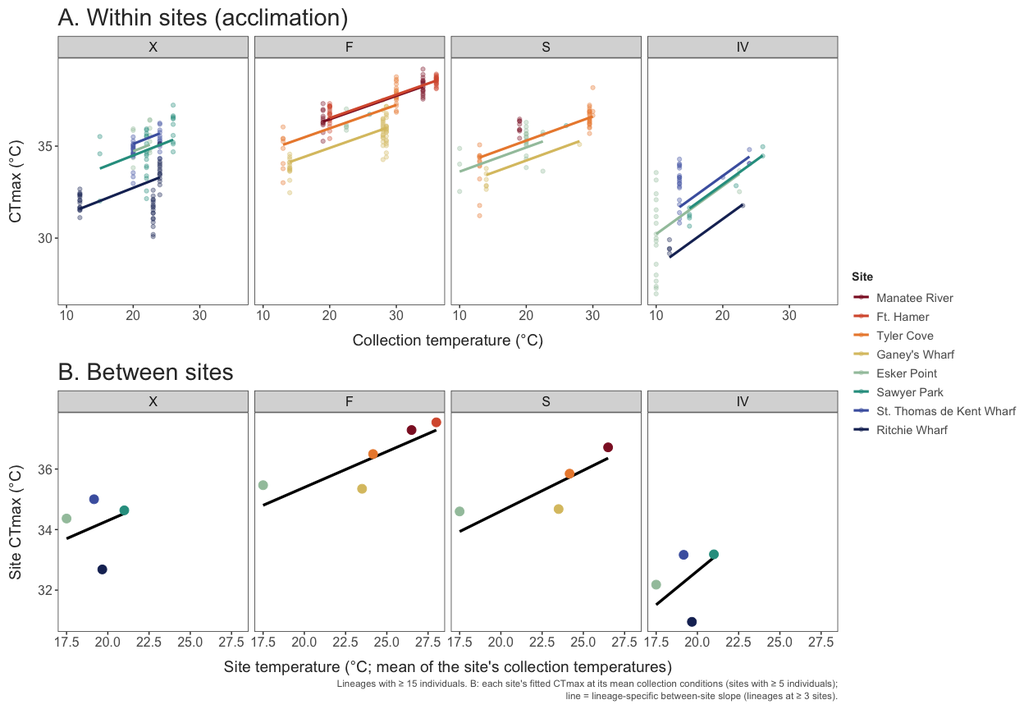

```r
plot_lins <- lin_n$lineage[lin_n$n >= 15]
pd <- filter(wb_data, lineage %in% plot_lins) %>% droplevels()
# (A) within site: each site's fitted CTmax across its own collection temperatures
wb_within_lines <- pd %>%
  reframe(t_within = range(t_within),
          .by = c(lineage, lin_w, lin_b, site, site_code, site_mean_collection, t_between)) %>%
  mutate(temp = site_mean_collection + t_within)
wb_within_lines$fit <- predict(wb_int, newdata = wb_within_lines, re.form = ~ (1 | site))

p_within <- ggplot(pd, aes(x = collection_temp, y = ctmax)) +
  geom_point(aes(colour = site), alpha = 0.35, size = 1.5) +
  geom_line(data = wb_within_lines, aes(x = temp, y = fit, colour = site, group = site), linewidth = 1.1) +
  facet_wrap(~ lineage, nrow = 1) +
  scale_colour_manual(values = site_cols) +
  labs(x = "Collection temperature (°C)", y = "CTmax (°C)", colour = "Site",
       title = "A. Within sites (acclimation)") +
  theme_matt_facets(base_size = 12)

# (B) between sites: each site's CTmax at its own mean collection conditions (no within-site
# deviation; fixed effects + site effect) against the site temperature; line = between-site
# slope, drawn for lineages with their own slope (>= 3 sites)
wb_site_pts <- pd %>%
  group_by(lineage, lin_w, lin_b, site, site_code, site_mean_collection, site_temp, t_between) %>%
  summarise(n = n(), .groups = "drop") %>%
  filter(n >= 5) %>%
  mutate(t_within = 0)
wb_site_pts$fit <- predict(wb_int, newdata = wb_site_pts, re.form = ~ (1 | site))
wb_between_line <- wb_site_pts %>%
  filter(lineage %in% est_b) %>%
  reframe(t_between = seq(min(t_between), max(t_between), length.out = 20), .by = c(lineage, lin_w, lin_b)) %>%
  mutate(t_within = 0, site_temp = t_between + mean(wb_events$site_temp))
wb_between_line$fit <- predict(wb_int, newdata = wb_between_line, re.form = NA)

p_between <- ggplot(wb_site_pts, aes(x = site_temp, y = fit)) +
  geom_line(data = wb_between_line, colour = "black", linewidth = 1.2) +
  geom_point(aes(colour = site), size = 3.5) +
  facet_wrap(~ lineage, nrow = 1, drop = FALSE) +
  scale_colour_manual(values = site_cols) +
  labs(x = paste0("Site temperature (°C; ", wb_source, ")"), y = "Site CTmax (°C)", colour = "Site",
       title = "B. Between sites",
       caption = "Lineages with ≥ 15 individuals. B: each site's fitted CTmax at its mean collection conditions (sites with ≥ 5 individuals);\nline = lineage-specific between-site slope (lineages at ≥ 3 sites).") +
  theme_matt_facets(base_size = 12)

ggarrange(p_within, p_between, ncol = 1, common.legend = TRUE, legend = "right")
```

CTmax rises by 0.15 °C for every 1 °C of within-site temperature change (95% CI 0.10–0.19), with lineage-specific acclimation slopes of 0.13 to 0.26. The between-site slope is 0.26 (CI 0.05 to 0.47; site temperature: mean of the site’s collection temperatures), and the difference between the two is 0.11 (CI -0.10 to 0.32). If that interval includes zero, CTmax differences between sites within a lineage are consistent with acclimation to each site’s temperature, with no detectable local adaptation beyond it; with only 1–5 sites per lineage, the test can rule out only large differences between the slopes. Panel B shows the site-level pattern behind the between-site slope: each point is a site’s CTmax at its own mean collection conditions.

The Stage 1 clade calls (Section 3.1) were merged with the CTmax and body size data set to examine clade-specific patterns of divergence. By plotting CTmax and size against the collection temperature we can see that these clades appear to be physiologically differentiated. Clades F and S tend to have higher CTmax, even when collected at the same temperatures as Clades X and IV. Size is more variable, with varying degrees of temperature sensitivity across the clades. Overall, however, Clade F tends to be smaller than Clades S and X. Clade IV tended to be the largest.

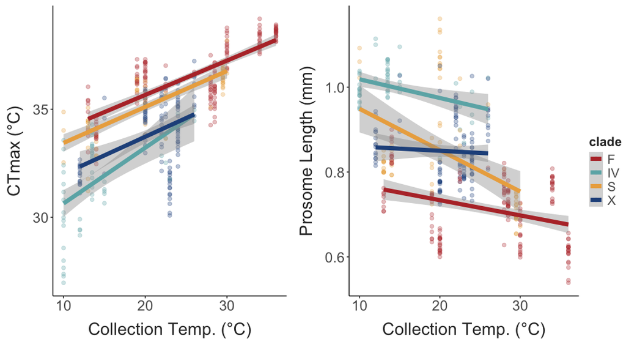

```r
clade_ctmax_plot = join_data %>%
  drop_na(clade) %>%
  filter(clade != "A_hudsonica") %>%
  ggplot(aes(x = collection_temp, y = ctmax, colour = clade)) +
  geom_point(size = 2, alpha = 0.3) +
  geom_smooth(method = "lm", linewidth = 2.5) +
  labs(x = "Collection Temp. (°C)",
       y = "CTmax (°C)") +
  scale_colour_manual(values = clade_cols) +
  theme_matt() +
  theme(legend.position = "none")

clade_size_plot =  join_data %>%
  drop_na(clade) %>%
  filter(clade != "A_hudsonica") %>%
  ggplot(aes(x = collection_temp, y = size, colour = clade)) +
  geom_point(size = 2, alpha = 0.3) +
  geom_smooth(method = "lm", linewidth = 2.5) +
  labs(x = "Collection Temp. (°C)",
       y = "Prosome Length (mm)") +
  scale_colour_manual(values = clade_cols) +
  theme_matt() +
  theme(legend.position = "none")

ggarrange(clade_ctmax_plot, clade_size_plot, nrow = 1, common.legend = T, legend = "right")
```

```r
# ggplot(clade_ctmax, aes(x = size, y = ctmax, colour = Clade)) +
#   geom_point(size = 2) +
#   #geom_smooth(method = "lm", linewidth = 2) +
#     labs(y = "CTmax (°C)",
#        x = "Prosome Length (mm)") +
#   scale_colour_manual(values = c("A_hudsonica" = "#1B9E99",
#                                "A_lilljeborgi" = "#D95F02",
#                                "F" = "#7570B3",
#                                "IV" = "#E7298A",
#                                "out_group" = "#666666",
#                                "S" = "#66A61E",
#                                "SB" = "#E6AB02",
#                                "X" = "#A6761D"),
#                     na.value = "black") +
#   theme_matt_facets()
```

```r
ctmax_contrast_plot = emmeans::emmeans(ctmax.model, specs = "clade") %>%
  data.frame() %>%
  mutate(clade = fct_relevel(clade, "F", "S", "X", "IV"))  %>%
  ggplot(aes(x = clade, y = emmean, colour = clade)) +
  geom_errorbar(aes(ymin = emmean - SE, ymax = emmean + SE),
                width = 0.3, linewidth = 2) +
  geom_point(size = 8) +
  labs(y = "Marginal Mean CTmax (°C)",
       x = "Clade") +
  scale_colour_manual(values = clade_cols) +
  theme_matt() +
  theme(legend.position = "none")
```

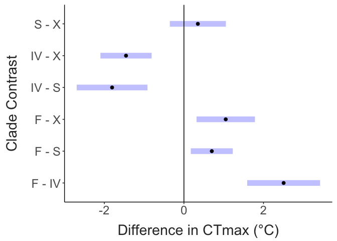

```r
emmeans::emmeans(ctmax.model, specs = "clade") %>% pairs() %>%  plot() +
  geom_vline(xintercept = 0) +
  labs(x = "Difference in CTmax (°C)",
       y = "Clade Contrast") +
  theme_matt()
```

```r
plast_contrast_plot = emmeans::emtrends(ctmax.model, var = "temp_cent", specs = "clade") %>%
  data.frame() %>%
  mutate(clade = fct_relevel(clade, "F", "S", "X", "IV"))  %>%
  ggplot(aes(x = clade, y = temp_cent.trend, colour = clade)) +
  geom_errorbar(aes(ymin = temp_cent.trend - SE, ymax = temp_cent.trend + SE),
                width = 0.3, linewidth = 2) +
  geom_point(size = 8) +
  labs(y = "Marginal CTmax Trend (°C/°C)",
       x = "Clade") +
  scale_colour_manual(values = clade_cols) +
  theme_matt() +
  theme(legend.position = "none")
```

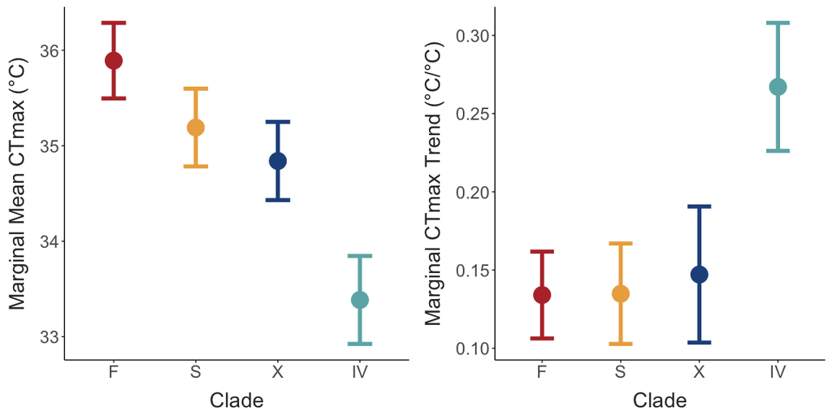

```r
ggarrange(ctmax_contrast_plot, plast_contrast_plot)
```

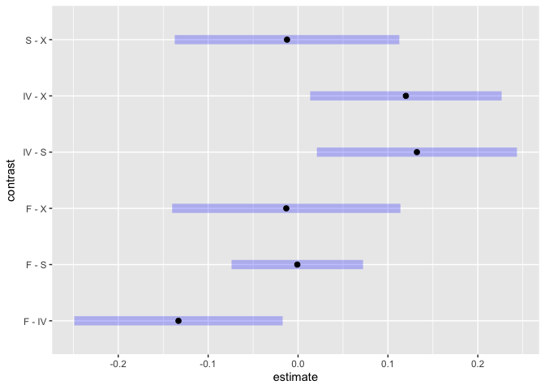

```r
emmeans::emtrends(ctmax.model, var = "temp_cent", specs = "clade") %>% pairs() %>% plot()
```

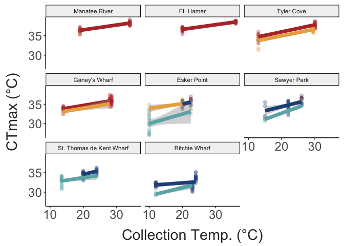

```r
join_data %>%
  drop_na(clade) %>%
  filter(clade != "A_hudsonica") %>%
  ggplot(aes(x = collection_temp, y = ctmax, colour = clade)) +
  facet_wrap(site~.) +
  geom_point(size = 2, alpha = 0.3) +
  geom_smooth(method = "lm", linewidth = 2.5) +
  labs(x = "Collection Temp. (°C)",
       y = "CTmax (°C)") +
  scale_colour_manual(values = clade_cols) +
  theme_matt() +
  theme(legend.position = "none")
```

These differences in physiology correspond to the distributional patterns for each clade. Using a Loess smoother (span = 2) highlights how the proportional abundance of the clades is affected by temperature in different ways. Clade F occurs in high proportion at high temperature, Clade IV occurs in high proportions at low temperatures, while Clade X occurs in high proportions at intermediate temperatures. Clade S generally occurs in low proportions, with a few exceptions.

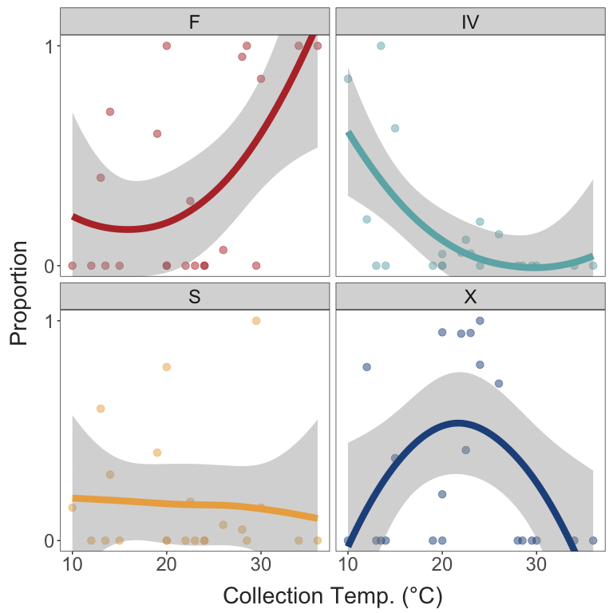

```r
clade_prop = join_data %>%
  filter(clade != "A_hudsonica") %>%
  drop_na(clade) %>%
  select(site, season, clade, collection_temp,collection_salinity, lat) %>%
  group_by(site, season, collection_temp, collection_salinity, lat) %>%
  count(clade) %>%
  ungroup(collection_temp, collection_salinity, lat) %>%
  mutate("prop" = n / sum(n)) %>%
  ungroup() %>%
  complete(nesting(site, season, collection_temp, collection_salinity, lat), clade, fill = list(prop = 0, n = 0)) %>%
  mutate(n = if_else(n == 0, 0, 1),
         num_season = case_when(
           season == "early" ~ 1,
           season == "peak" ~ 2,
           season == "late" ~ 3))

clade_prop %>%
  ggplot(aes(x = collection_temp, y = prop, colour = clade)) +
  facet_wrap(clade~.) +
  geom_point(size = 3, alpha = 0.5) +
  geom_smooth(
    method = 'loess',
    formula = 'y ~ x',
    span = 2,
    se = T,
    linewidth = 3) +
  labs(x = "Collection Temp. (°C)",
       y = "Proportion") +
  coord_cartesian(ylim = c(0,1)) +
  scale_y_continuous(breaks = c(0,1)) +
  scale_colour_manual(values = clade_cols) +
  theme_matt_facets() +
  theme(legend.position = "none")
```

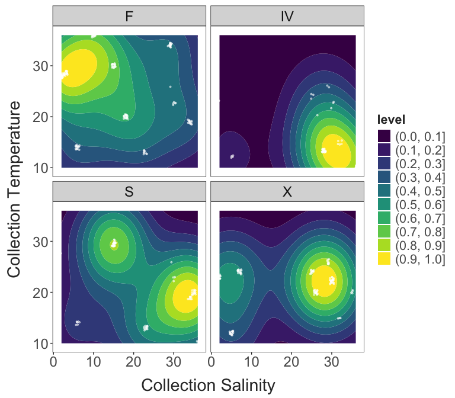

```r
join_data %>%
  drop_na(clade) %>%
  filter(clade != "A_hudsonica") %>%
  select(collection_temp, collection_salinity, clade) %>%
  ggplot(aes(y = collection_temp, x = collection_salinity)) +
  facet_wrap(clade~.) +
  geom_density_2d_filled(contour_var = "ndensity",
                         h = c(25, 25)) +
  geom_point(colour = "white", size = 0.7, alpha = 0.5,
             position = position_jitter(width = 0.5, height = 0.5)) +
  labs(x = "Collection Salinity",
       y = "Collection Temperature") +
  theme_matt_facets()
```

### Partitioning CTmax variation

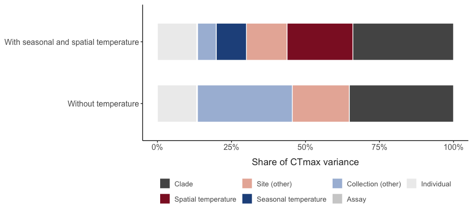

```r
vp_data <- wb_data %>% mutate(collection = paste(site_code, season, sep = "_"))
vp_m0 <- lme4::lmer(ctmax ~ 1 + (1 | lineage) + (1 | site) + (1 | collection) + (1 | replicate) + (1 | tube),
                    data = vp_data)
vp_m1 <- lme4::lmer(ctmax ~ t_time + t_space + (1 | lineage) + (1 | site) + (1 | collection) +
                      (1 | replicate) + (1 | tube), data = vp_data)

vp_shares <- function(m) {
  vc <- as.data.frame(lme4::VarCorr(m))
  re <- setNames(vc$vcov, vc$grp)
  b <- lme4::fixef(m)
  # season-mean split (as in Fig. 3A): seasonal = season mean across sites, spatial = deviation within season
  fx <- c(t_time = NA_real_, t_space = NA_real_)
  if ("t_time" %in% names(b)) fx <- c(t_time = var(b[["t_time"]] * m@frame$t_time),
                                      t_space = var(b[["t_space"]] * m@frame$t_space))
  comp <- c(Clade = re[["lineage"]], `Spatial temperature` = unname(fx["t_space"]),
            `Site (other)` = re[["site"]], `Seasonal temperature` = unname(fx["t_time"]),
            `Collection (other)` = re[["collection"]],
            Assay = re[["replicate"]] + re[["tube"]], Individual = re[["Residual"]])
  comp[is.na(comp)] <- 0
  comp / sum(comp)
}
set.seed(1)
vp_boot <- function(m) {
  bt <- lme4::bootMer(m, vp_shares, nsim = 200, type = "parametric", use.u = FALSE)
  tibble(component = names(bt$t0), share = bt$t0,
         lo = apply(bt$t, 2, quantile, 0.025, na.rm = TRUE), hi = apply(bt$t, 2, quantile, 0.975, na.rm = TRUE))
}
vp_tab <- bind_rows(vp_boot(vp_m0) %>% mutate(model = "Without temperature"),
                    vp_boot(vp_m1) %>% mutate(model = "With seasonal and spatial temperature")) %>%
  mutate(component = factor(component, levels = names(vp_shares(vp_m1))),
         model = factor(model, levels = c("Without temperature", "With seasonal and spatial temperature")))

vp_cols <- c(Clade = "#555555", `Spatial temperature` = unname(lat_gradient["MR"]), `Site (other)` = "#E8B4A6",
             `Seasonal temperature` = unname(lat_gradient["X"]), `Collection (other)` = "#A9BCD9",
             Assay = "#D0D0D0", Individual = "#EDEDED")
ggplot(filter(vp_tab, share > 0), aes(x = model, y = share, fill = component)) +
  geom_col(width = 0.6, colour = "white") +
  coord_flip() +
  scale_y_continuous(labels = scales::percent) +
  scale_fill_manual(values = vp_cols, name = NULL) +
  guides(fill = guide_legend(nrow = 2)) +
  labs(x = NULL, y = "Share of CTmax variance") +
  theme_matt(base_size = 12) +
  theme(legend.position = "bottom")
```

```r
vp_tab %>%
  filter(share > 0) %>%
  mutate(value = sprintf("%.0f%% (%.0f–%.0f)", 100 * share, 100 * lo, 100 * hi)) %>%
  select(component, model, value) %>%
  pivot_wider(names_from = model, values_from = value, values_fill = "–") %>%
  arrange(component) %>%
  knitr::kable(col.names = c("Component", "Without temperature", "With seasonal and spatial temperature"),
               caption = "Share of CTmax variance (95% parametric bootstrap interval).")
```

Share of CTmax variance (95% parametric bootstrap interval).

| Component | Without temperature | With seasonal and spatial temperature |
| --- | --- | --- |
| Clade | 35% (3–66) | 34% (2–64) |
| Spatial temperature | – | 22% (7–42) |
| Site (other) | 19% (0–54) | 14% (1–33) |
| Seasonal temperature | – | 10% (5–22) |
| Collection (other) | 32% (11–63) | 6% (2–14) |
| Assay | 0% (0–1) | 0% (0–1) |
| Individual | 13% (7–23) | 13% (8–23) |

Without temperature terms, the largest components are collection (32%), clade (35%) and site (19%), with 13% among individuals within a collection. The temperature terms follow the season-mean split of Fig. 3A: seasonal temperature (the season’s mean collection temperature across sites) explains 10% of all CTmax variance, and spatial temperature (a collection’s deviation from that season mean) 22%; together they absorb most of the collection component (which drops to 6%), leaving 14% to other site differences. Clade accounts for 34%. The intervals are wide because clade and site have few levels (4 clades, 8 sites).

### Lineage differences under shared conditions (natural common garden)

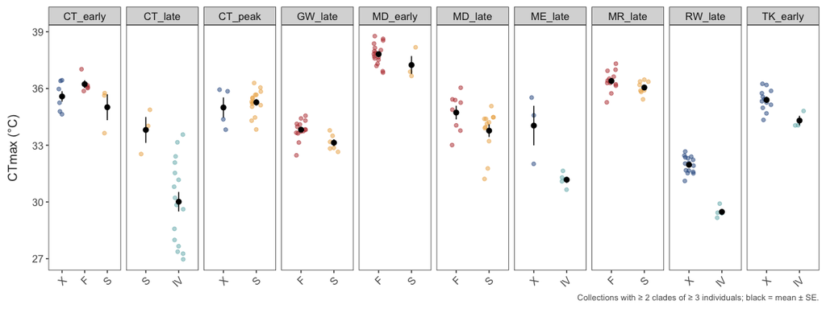

```r
cg_all <- wb_data %>% mutate(collection = paste(site_code, season, sep = "_"))
cg_keep <- cg_all %>%
  count(collection, lineage) %>%
  filter(n >= 3) %>%
  group_by(collection) %>% filter(n() >= 2) %>% ungroup()
cg <- semi_join(cg_all, cg_keep, by = c("collection", "lineage")) %>% droplevels()
cg_model <- lm(ctmax ~ collection + lineage, data = cg)
cg_pairs <- cg_keep %>%
  group_by(collection) %>%
  summarise(pairs = list(combn(sort(as.character(lineage)), 2, paste, collapse = " – ")), .groups = "drop") %>%
  unnest(pairs) %>% count(pairs, name = "collections")
cg_emm <- emmeans::emmeans(cg_model, ~ lineage)
cg_con <- as_tibble(summary(pairs(cg_emm, adjust = "none"), infer = TRUE)) %>%
  mutate(pair = str_remove_all(str_replace_all(contrast, " - ", " – "), "[()]")) %>%
  mutate(pair_sorted = map_chr(str_split(pair, " – "), ~ paste(sort(.x), collapse = " – ")),
         sign = if_else(pair == pair_sorted, 1, -1),
         estimate = sign * estimate, lo = if_else(sign == 1, lower.CL, -upper.CL),
         hi = if_else(sign == 1, upper.CL, -lower.CL)) %>%
  inner_join(cg_pairs, by = c("pair_sorted" = "pairs")) %>%
  select(pair = pair_sorted, collections, estimate, lo, hi, p.value)
# the same contrasts from all collections (within/between model: lineage effects at equal temperature)
all_emm <- emmeans::emmeans(wb_add, ~ lineage)
all_con <- as_tibble(summary(pairs(all_emm, adjust = "none"), infer = TRUE)) %>%
  mutate(pair = str_remove_all(str_replace_all(contrast, " - ", " – "), "[()]"),
         pair_sorted = map_chr(str_split(pair, " – "), ~ paste(sort(.x), collapse = " – ")),
         sign = if_else(pair == pair_sorted, 1, -1),
         est_all = sign * estimate, lo_all = if_else(sign == 1, lower.CL, -upper.CL),
         hi_all = if_else(sign == 1, upper.CL, -lower.CL)) %>%
  select(pair = pair_sorted, est_all, lo_all, hi_all)
cg_tab <- left_join(cg_con, all_con, by = "pair")

cg_plot <- cg %>%
  mutate(clade = factor(if_else(str_detect(lineage, "^F"), "F", as.character(lineage)), levels = tonsa_clades))
ggplot(cg_plot, aes(x = lineage, y = ctmax, colour = clade)) +
  geom_jitter(width = 0.15, height = 0, alpha = 0.5, size = 1.6) +
  stat_summary(fun.data = mean_se, colour = "black", size = 0.4) +
  facet_wrap(~ collection, nrow = 1, scales = "free_x") +
  scale_colour_manual(values = clade_cols[tonsa_clades], guide = "none") +
  labs(x = NULL, y = "CTmax (°C)", caption = "Collections with ≥ 2 clades of ≥ 3 individuals; black = mean ± SE.") +
  theme_matt_facets(base_size = 11) +
  theme(axis.text.x = element_text(angle = 45, hjust = 1))
```

```r
cg_tab %>%
  transmute(`Lineage pair (first − second)` = pair, `Shared collections` = collections,
            `Within shared collections` = sprintf("%.2f (%.2f, %.2f)", estimate, lo, hi),
            p = signif(p.value, 2),
            `All collections (temperature-adjusted)` = sprintf("%.2f (%.2f, %.2f)", est_all, lo_all, hi_all)) %>%
  knitr::kable(caption = "CTmax differences (°C, 95% CI) between lineages that co-occur in at least one collection: estimated only within shared collections, and from all collections in the within/between model.")
```

CTmax differences (°C, 95% CI) between lineages that co-occur in at least one collection: estimated only within shared collections, and from all collections in the within/between model.

| Lineage pair (first − second) | Shared collections | Within shared collections | p | All collections (temperature-adjusted) |
| --- | --- | --- | --- | --- |
| F – X | 1 | 1.01 (0.28, 1.73) | 0.0066 | 1.13 (0.56, 1.69) |
| S – X | 2 | 0.37 (-0.29, 1.03) | 0.2700 | 0.50 (-0.01, 1.01) |
| IV – X | 3 | -2.46 (-3.09, -1.83) | 0.0000 | -1.97 (-2.38, -1.55) |
| F – S | 5 | 0.63 (0.20, 1.07) | 0.0048 | 0.63 (0.25, 1.00) |
| IV – S | 1 | -2.83 (-3.61, -2.06) | 0.0000 | -2.47 (-3.03, -1.91) |

#### Does lineage turnover change seasonal thermal tolerance?

If lineages differ heritably in CTmax and their make-up changes through the season, turnover alone shifts the CTmax a collection would have, independent of acclimation. For each collection, the expected CTmax from composition alone is the composition-weighted mean of the lineage effects (temperature-adjusted lineage means from the within/between model). Its within-site slope against collection temperature (site as a fixed effect, weighted by individuals) is compared with the within-site acclimation slope. The null shuffles lineage labels among individuals across the seasons of each site (10⁴ permutations), keeping each site’s lineages but removing their timing.

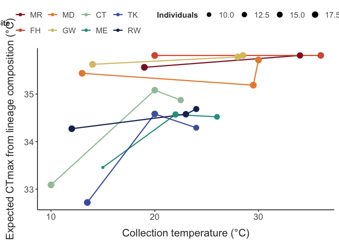

```r
lin_eff <- as_tibble(summary(emmeans::emmeans(wb_add, ~ lineage))) %>%
  transmute(lineage = as.character(lineage), mu = emmean)
comp_t <- comp %>% filter(as.character(lineage) %in% lin_eff$lineage) %>%
  mutate(mu = lin_eff$mu[match(as.character(lineage), lin_eff$lineage)])
coll_exp <- function(d) d %>% group_by(site_code, season) %>%
  summarise(exp_ctmax = mean(mu), temp = mean(collection_temp, na.rm = TRUE), n = n(), .groups = "drop")
turn_slope <- function(ce) {
  ce <- ce %>% group_by(site_code) %>% filter(n() > 1) %>% ungroup()
  unname(coef(lm(exp_ctmax ~ site_code + temp, data = ce, weights = n))["temp"])
}
ce_obs <- coll_exp(comp_t)
slope_obs <- turn_slope(ce_obs)
set.seed(2)
by_site_t <- split(comp_t, comp_t$site_code, drop = TRUE)
slope_null <- replicate(1e4, {
  d <- map_dfr(by_site_t, function(x) { x$mu <- sample(x$mu); x })
  turn_slope(coll_exp(d))
})
slope_p <- (sum(abs(slope_null) >= abs(slope_obs)) + 1) / (length(slope_null) + 1)
acc_slope <- unname(lme4::fixef(wb_add)["t_within"])

ce_obs %>%
  group_by(site_code) %>% filter(n() > 1) %>% ungroup() %>%
  mutate(site_code = factor(site_code, levels = site_order)) %>%
  ggplot(aes(x = temp, y = exp_ctmax, colour = site_code, group = site_code)) +
  geom_line(linewidth = 0.8) +
  geom_point(aes(size = n)) +
  scale_colour_manual(values = pop_cols[site_order], name = "Site") +
  scale_size_continuous(range = c(1.5, 4), name = "Individuals") +
  labs(x = "Collection temperature (°C)", y = "Expected CTmax from lineage composition (°C)") +
  theme_matt(base_size = 13)
```

Composition alone shifts expected CTmax by 0.04 °C per °C of collection temperature within sites (permutation p < 0.001), compared with an acclimation slope of 0.15 °C per °C within lineages: turnover adds about 26% to the seasonal change that acclimation produces. Collections are dominated by more tolerant lineages when the water is warm and by less tolerant lineages (above all IV) when it is cool, so turnover reinforces acclimation rather than opposing it. This is a seasonal change in thermal tolerance with a heritable basis that happens through the sorting of lineages, not evolution within them. Caveat: composition comes from the individuals sequenced per collection (about 20), so proportions are coarse, and collections were sampled in one year.

### Genetic basis of CTmax within collections

Is CTmax variation among individuals collected together associated with particular genetic variants? Within each lineage with ≥ 30 phenotyped and sequenced individuals (collections with ≥ 8 individuals of the lineage: X 104, F-N 78, S 54, F-FH 38, IV 36), CTmax was regressed on genotype dosage (the expected number of minor alleles, from ANGSD genotype posteriors) at every SNP, with collection and log mean sequencing depth as covariates. Collection absorbs acclimation and population differences, so individuals are compared only with others collected at the same time and place; depth is included because at < 1× coverage deeper individuals show more minor alleles, which would otherwise bias every SNP’s effect if depth tracks CTmax (it does, weakly: +0.26 °C per log unit of depth within collections, all lineages pooled). Individuals without reads at a SNP were given their collection’s mean dosage. Body size was not included. Genome-wide calibration comes from 100 replicates with CTmax shuffled among individuals of the same collection, which keep each collection’s CTmax distribution and all genotype structure but break any genotype–phenotype link.

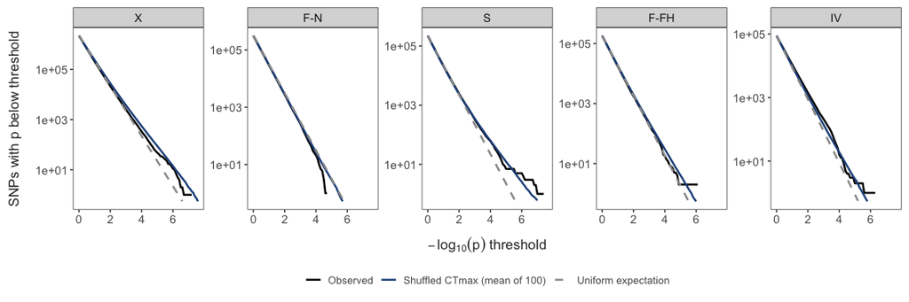

```r
gwas_lins <- c("X", "F-N", "S", "F-FH", "IV")
gwas_qq_files <- cx("results", "16_gwas", paste0(gwas_lins, ".qq.tsv"))
if (!all(file.exists(gwas_qq_files))) {
  cat("CTmax association results are not in this export yet.")
} else {
  gwas_qq <- map2_dfr(gwas_lins, gwas_qq_files, function(l, f) {
    read_tsv(f, show_col_types = FALSE) %>% mutate(lineage = l)
  }) %>%
    group_by(lineage) %>%
    arrange(desc(bin_lo), .by_group = TRUE) %>%
    mutate(n_snps = sum(observed),
           Observed = cumsum(observed), `Shuffled CTmax (mean of 100)` = cumsum(perm_mean),
           `Uniform expectation` = n_snps * 10^(-bin_lo)) %>%
    ungroup() %>%
    pivot_longer(c(Observed, `Shuffled CTmax (mean of 100)`, `Uniform expectation`),
                 names_to = "series", values_to = "count") %>%
    filter(count >= 0.5, bin_lo <= 8) %>%
    mutate(lineage = factor(lineage, levels = gwas_lins))
  ggplot(gwas_qq, aes(x = bin_lo, y = count, colour = series, linetype = series)) +
    geom_line(linewidth = 0.9) +
    facet_wrap(~ lineage, nrow = 1, scales = "free_y") +
    scale_y_log10() +
    scale_colour_manual(values = c(Observed = "black", `Shuffled CTmax (mean of 100)` = unname(lat_gradient["X"]),
                                   `Uniform expectation` = "grey60"), name = NULL) +
    scale_linetype_manual(values = c(Observed = "solid", `Shuffled CTmax (mean of 100)` = "solid",
                                     `Uniform expectation` = "dashed"), name = NULL) +
    labs(x = expression(-log[10](p) ~ "threshold"), y = "SNPs with p below threshold") +
    theme_matt_facets(base_size = 11) +
    theme(legend.position = "bottom")
}
```

```r
gwas_rank_files <- cx("results", "16_gwas", paste0(gwas_lins, ".rank.tsv"))
if (all(file.exists(gwas_rank_files))) {
  gwas_rank <- map2_dfr(gwas_lins, gwas_rank_files, function(l, f) {
    read_tsv(f, show_col_types = FALSE) %>% mutate(lineage = l)
  }) %>% filter(snp_set == "all")
  gwas_snps <- map_dfr(gwas_lins, function(l) {
    read_tsv(cx("results", "16_gwas", paste0(l, ".summary.tsv")), show_col_types = FALSE) %>%
      filter(perm == 0, snp_set == "all") %>% transmute(lineage = l, snps)
  })
  gwas_rank %>%
    mutate(value = if_else(statistic == "lambda",
                           sprintf("%.2f vs %.2f (%d)", observed, perm_mean, rank),
                           sprintf("%.0f vs %.0f (%d)", observed, perm_mean, rank))) %>%
    select(lineage, statistic, value) %>%
    pivot_wider(names_from = statistic, values_from = value) %>%
    left_join(gwas_snps, by = "lineage") %>%
    relocate(snps, .after = lineage) %>%
    mutate(lineage = factor(lineage, levels = gwas_lins)) %>% arrange(lineage) %>%
    knitr::kable(col.names = c("Lineage", "SNPs", "λ", "p < 10⁻³", "p < 10⁻⁴", "p < 10⁻⁵", "p < 10⁻⁶"),
                 caption = "Observed vs. mean of 100 within-collection CTmax shuffles (rank of the observed value among the 101; 1 = larger than every shuffle).")
}
```

Observed vs. mean of 100 within-collection CTmax shuffles (rank of the observed value among the 101; 1 = larger than every shuffle).

| Lineage | SNPs | λ | p < 10⁻³ | p < 10⁻⁴ | p < 10⁻⁵ | p < 10⁻⁶ |
| --- | --- | --- | --- | --- | --- | --- |
| X | 2209940 | 0.95 vs 1.04 (94) | 2570 vs 3743 (91) | 338 vs 553 (89) | 48 vs 88 (86) | 11 vs 14 (63) |
| F-N | 313838 | 0.95 vs 0.97 (65) | 265 vs 274 (52) | 21 vs 27 (73) | 0 vs 3 (101) | 0 vs 0 (101) |
| S | 223199 | 0.96 vs 0.94 (41) | 332 vs 355 (54) | 62 vs 63 (50) | 7 vs 12 (85) | 5 vs 3 (16) |
| F-FH | 183335 | 0.97 vs 1.00 (65) | 195 vs 232 (67) | 18 vs 30 (91) | 2 vs 4 (85) | 2 vs 1 (15) |
| IV | 88781 | 1.15 vs 1.05 (6) | 212 vs 140 (6) | 16 vs 19 (64) | 2 vs 3 (74) | 1 vs 0 (29) |

```r
if (exists("gwas_conc")) {
  gwas_conc %>%
    transmute(Lineage = lineage, Comparison = comparison, `Unlinked SNPs` = snps,
              r = sprintf("%.3f", r), `Shuffle SD of r` = sprintf("%.3f", perm_sd), Rank = paste0(rank, " / 101")) %>%
    knitr::kable(caption = "Correlation between each SNP's CTmax effect (t) and its spatial or seasonal temperature slope (z), against 100 within-collection CTmax shuffles (two-sided rank).")
}
```

Correlation between each SNP’s CTmax effect (t) and its spatial or seasonal temperature slope (z), against 100 within-collection CTmax shuffles (two-sided rank).

| Lineage | Comparison | Unlinked SNPs | r | Shuffle SD of r | Rank |
| --- | --- | --- | --- | --- | --- |
| X | Spatial slope | 41784 | 0.011 | 0.053 | 90 / 101 |
| X | Seasonal slope | 41784 | -0.004 | 0.010 | 69 / 101 |
| S | Spatial slope | 17707 | 0.009 | 0.008 | 21 / 101 |
| S | Seasonal slope | 17707 | -0.008 | 0.017 | 59 / 101 |

```r
if (exists("gwas_sign")) {
  gwas_sign %>%
    transmute(Lineage = factor(lineage, levels = gwas_lins), `SNPs (freq < 0.15, |t| > 2.6)` = snps,
              `Observed` = sprintf("%.2f", observed),
              `Shuffles: mean (95% range)` = sprintf("%.2f (%.2f–%.2f)", perm_mean, lo, hi),
              Rank = paste0(rank, " / 101")) %>%
    arrange(Lineage) %>%
    knitr::kable(caption = "Fraction of the stronger associations at rare SNPs (minor-allele frequency < 0.15) in which the minor allele lowers CTmax, observed vs. shuffles.")
}
```

Fraction of the stronger associations at rare SNPs (minor-allele frequency < 0.15) in which the minor allele lowers CTmax, observed vs. shuffles.

| Lineage | SNPs (freq < 0.15, \|t\| > 2.6) | Observed | Shuffles: mean (95% range) | Rank |
| --- | --- | --- | --- | --- |
| X | 454 | 0.64 | 0.63 (0.54–0.71) | 41 / 101 |
| F-N | 94 | 0.69 | 0.58 (0.45–0.70) | 4 / 101 |
| S | 114 | 0.85 | 0.86 (0.78–0.93) | 66 / 101 |
| F-FH | 21 | 0.76 | 0.80 (0.56–0.96) | 73 / 101 |
| IV | 25 | 0.60 | 0.49 (0.25–0.70) | 21 / 101 |

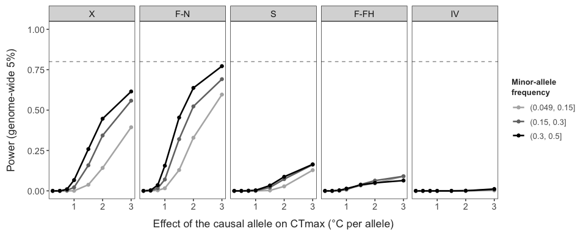

```r
gw_pw_files <- Sys.glob(cx("results", "16_gwas", "*.power.tsv"))
if (length(gw_pw_files) == 0) {
  cat("Association-scan power (results/16_gwas/*.power.tsv) is not in this export yet.")
} else {
  gw_pw <- map_dfr(gw_pw_files, read_tsv, show_col_types = FALSE) %>%
    mutate(lineage = factor(lineage, levels = c("X", "F-N", "S", "F-FH", "IV")),
           maf_bin = factor(maf_bin, levels = unique(maf_bin[order(parse_number(maf_bin))])))
  ggplot(gw_pw, aes(x = beta, y = power, colour = maf_bin)) +
    geom_hline(yintercept = 0.8, colour = "grey60", linetype = "dashed") +
    geom_line(linewidth = 0.9) + geom_point(size = 1.6) +
    facet_wrap(~ lineage, nrow = 1) +
    scale_colour_manual(values = c("grey70", "grey45", "black"), name = "Minor-allele\nfrequency") +
    scale_y_continuous(limits = c(0, 1)) +
    labs(x = "Effect of the causal allele on CTmax (°C per allele)", y = "Power (genome-wide 5%)") +
    theme_matt_facets(base_size = 11)
}
```

Power was simulated on each lineage’s own data (cluster target `gwas_power`): for 2,000 SNPs sampled across the genome, true genotypes were drawn from each individual’s genotype posterior, a causal effect was added to CTmax shuffled within collections, and the scan’s test was repeated against the genome-wide 5% threshold from its own permutations. Genotype accuracy was low (r² between expected dosage and true genotype 0.39–0.47), and the scan reached 50% power only for loci of about 2 °C per allele in F-N and 3 °C in X (explaining most of the within-collection CTmax variance); in S, F-FH and IV it never did. The scan rules out only loci of very large effect and does not constrain a polygenic basis of within-lineage variation; it is reported for completeness.

No lineage shows more association signal than the shuffles: the observed counts of small p values sit inside, and in X below, the shuffle distribution at every threshold, with or without chromosome 6. The one marginal exception is IV, where moderately small p values (p < 0.001) are more common than in 94 of 100 shuffles but the tail is not; with five lineages tested and the smallest sample (36 individuals, 2 collections), this is consistent with chance. The smallest individual p values (down to ~10⁻⁷–10⁻⁸) are typical of the shuffles too, and the top SNPs share a profile – low frequency, reads in only part of the individuals, large estimated effects – expected from chance at weakly informative sites, so none is reported as a candidate.

Two patterns that appeared in a first version of the scan (without the depth covariate, and with missing individuals given the overall rather than the collection mean) do not survive comparison with the shuffles. First, CTmax effects do not line up with the spatial or seasonal temperature slopes in X or S: the observed correlations (|r| ≤ 0.011) are well inside the shuffle distributions, whose spread (SD 0.01–0.05) is much larger than a chromosome jackknife suggests, because one shuffle shifts the effects of all SNPs together. Second, the excess of negative effects at rare SNPs (minor allele lowering CTmax) is reproduced by the shuffles (63–86% negative in X, S and F-FH, as observed), so it is a property of dosage regression at low-frequency sites, not evidence for deleterious rare variants; only F-N is slightly above its shuffles (0.69 vs. 0.58, rank 4 of 101), which with five lineages tested is not significant.

CTmax among individuals collected together therefore shows no detectable association with individual variants, no polygenic excess, and no link between the alleles that track temperature in space or season and those that affect CTmax. With 36–104 individuals per lineage this rules out only loci of large effect; it is consistent with the variance partition above, in which CTmax variation is dominated by lineage, acclimation and site.

### Candidate genes: mitochondrial amino-acid differences

Lineage differences in CTmax are heritable but, within lineages, no SNP associates with CTmax. The comparative alternative asks which protein differences between lineages could underlie them. Mitochondrial OXPHOS genes are the first candidates: they are inherited as a unit, they define the clades, and amino-acid changes in COX1, CYTB and other respiratory-chain subunits alter thermal performance in copepods (*Tigriopus californicus*: Willett 2010, Harada et al. 2019) and other ectotherms. The clade mitogenome contigs are unannotated de novo assemblies, so protein-coding genes were found as open reading frames (invertebrate mitochondrial code, ≥ 150 codons; COX1 and CYTB identified by conserved motifs, other ORFs by length and strand). ORFs nested inside an ORF on the opposite strand are flagged; one member of each such pair is probably not a gene. The F contig (16.1 kb) covers most of the mitogenome, so the four F lineages can be compared across 11 ORFs; the X and IV contigs (about 5 kb) cover only COX1, CYTB and one further ORF, so clades are compared there (`Scripts/07_mito_aa.R`).

```r
mito_dir <- here("Output", "Output_data", "mito_aa")
have_mito <- file.exists(file.path(mito_dir, "IV_specific_aa.csv"))
if (have_mito) {
  f_orfs <- read_csv(file.path(mito_dir, "F_lineage_orfs.csv"), show_col_types = FALSE)
  f_sites <- read_csv(file.path(mito_dir, "F_lineage_aa_sites.csv"), show_col_types = FALSE)
  cl_pairs <- read_csv(file.path(mito_dir, "clade_aa_pairs.csv"), show_col_types = FALSE)
  iv_aa <- read_csv(file.path(mito_dir, "IV_specific_aa.csv"), show_col_types = FALSE)
  # pairwise F-lineage amino-acid differences (both lineages fixed, >= 80%)
  f_fixed <- f_sites %>% filter(!is.na(state), freq >= 0.8)
  f_lins <- sort(unique(f_sites$lineage))
  f_pairs <- combn(f_lins, 2, simplify = FALSE) %>% map_dfr(\(p) {
    w <- f_fixed %>% filter(lineage %in% p) %>%
      select(gene, aa_pos, lineage, state) %>% pivot_wider(names_from = lineage, values_from = state) %>%
      filter(!is.na(.data[[p[1]]]), !is.na(.data[[p[2]]]))
    tibble(pair = paste(p, collapse = " – "), compared_genes = "all ORFs",
           differences = sum(w[[p[1]]] != w[[p[2]]]),
           differences_excl_ORF216 = sum(w[[p[1]]] != w[[p[2]]] & w$gene != "ORF216-"))
  })
}
```

```r
if (have_mito) {
  f_orfs %>%
    transmute(ORF = gene, Strand = strand, `Position (bp)` = paste(start, end, sep = "–"), Codons = codons,
              `Nested antisense` = if_else(nested_antisense, "yes", ""),
              `Fixed nt differences` = fixed_nt_differences, Nonsynonymous = nonsynonymous,
              Synonymous = synonymous) %>%
    knitr::kable(caption = "Open reading frames on the F mitogenome contig and nucleotide differences fixed (≥ 80% of ≥ 5 called individuals) between at least two F lineages.")
}
```

Open reading frames on the F mitogenome contig and nucleotide differences fixed (≥ 80% of ≥ 5 called individuals) between at least two F lineages.

| ORF | Strand | Position (bp) | Codons | Nested antisense | Fixed nt differences | Nonsynonymous | Synonymous |
| --- | --- | --- | --- | --- | --- | --- | --- |
| ORF559- | - | 788–2464 | 559 |  | 184 | 44 | 140 |
| ORF311+ | + | 2901–3833 | 311 |  | 87 | 15 | 72 |
| ORF435+ | + | 4259–5563 | 435 |  | 135 | 30 | 105 |
| ORF157- | - | 5928–6398 | 157 |  | 40 | 12 | 28 |
| COX1 | + | 7456–8997 | 514 |  | 132 | 3 | 129 |
| CYTB | + | 9072–10217 | 382 |  | 111 | 9 | 102 |
| ORF129- | - | 9536–9922 | 129 | yes | 42 | 4 | 38 |
| ORF316+ | + | 11689–12636 | 316 |  | 107 | 32 | 75 |
| ORF155- | - | 11715–12179 | 155 | yes | 41 | 15 | 26 |
| ORF219- | - | 14127–14783 | 219 |  | 66 | 10 | 56 |
| ORF216- | - | 14950–15597 | 216 |  | 71 | 53 | 18 |

```r
if (have_mito) {
  f_pairs %>% select(-compared_genes) %>%
    rename(`Lineage pair` = pair, `Amino-acid differences` = differences,
           `Excluding ORF216-` = differences_excl_ORF216) %>%
    knitr::kable(caption = "Fixed amino-acid differences between F lineages, all ORFs on the F contig.")
}
```

Fixed amino-acid differences between F lineages, all ORFs on the F contig.

| Lineage pair | Amino-acid differences | Excluding ORF216- |
| --- | --- | --- |
| F-FH – F-MR | 52 | 52 |
| F-FH – F-N | 86 | 86 |
| F-FH – F-NE | 89 | 89 |
| F-MR – F-N | 95 | 91 |
| F-MR – F-NE | 100 | 96 |
| F-N – F-NE | 73 | 32 |

```r
if (have_mito) {
  cl_pairs %>%
    mutate(value = sprintf("%d / %d", differences, aligned_aa)) %>%
    mutate(pair = str_replace(pair, "-", " – ")) %>%
    select(gene, pair, value) %>%
    pivot_wider(names_from = gene, values_from = value) %>%
    rename(`Clade pair` = pair, `ORF (LQDA)` = ORF_LQDA) %>%
    knitr::kable(caption = "Amino-acid differences between clade consensus proteins (differences / aligned positions) in the three genes covered by all four clade contigs.")
}
```

Amino-acid differences between clade consensus proteins (differences / aligned positions) in the three genes covered by all four clade contigs.

| Clade pair | COX1 | CYTB | ORF (LQDA) |
| --- | --- | --- | --- |
| F – S | 5 / 495 | 26 / 366 | 17 / 205 |
| F – X | 2 / 495 | 15 / 364 | 13 / 207 |
| F – IV | 10 / 495 | 31 / 366 | 22 / 204 |
| S – X | 5 / 495 | 30 / 364 | 13 / 205 |
| S – IV | 11 / 495 | 39 / 367 | 18 / 202 |
| X – IV | 8 / 495 | 32 / 364 | 18 / 206 |

```r
if (have_mito) {
  iv_aa %>%
    rename(Gene = gene, `Position (F protein)` = pos_F, `F, S, X` = F_S_X, `Context (F)` = context_F) %>%
    knitr::kable(caption = "Substitutions unique to IV, the low-CTmax clade (IV differs; F, S and X share the state).")
}
```

Substitutions unique to IV, the low-CTmax clade (IV differs; F, S and X share the state).

| Gene | Position (F protein) | F, S, X | IV | Context (F) |
| --- | --- | --- | --- | --- |
| COX1 | 176 | M | L | LRSFGMVLDLM |
| COX1 | 415 | G | A | LKAQFGMMFLG |
| COX1 | 416 | M | T | KAQFGMMFLGV |
| COX1 | 467 | Y | F | VISIMYFLFIL |
| COX1 | 495 | Y | F | SSLEXYHSFPP |
| COX1 | 512 | I | S | SIPVVISK |
| COX1 | 514 | K | S | PVVISK |
| CYTB | 7 | I | V | KQLKXISPVTK |
| CYTB | 20 | E | D | FGSVVELPTPS |
| CYTB | 105 | G | S | RGLYYGSYYFS |
| CYTB | 110 | S | T | GSYYFSHTWLV |
| CYTB | 159 | D | E | PYLGGDLVLWM |
| CYTB | 184 | L | F | FSLHFLIPFVV |
| CYTB | 188 | V | I | FLIPFVVAAMS |
| CYTB | 192 | M | L | FVVAAMSAVHL |
| CYTB | 324 | M | T | PLSKMMFWIQI |
| CYTB | 334 | L | M | IXIVILLTWIG |
| CYTB | 353 | I | T | IVIGQILSVVY |
| CYTB | 360 | S | L | SVVYFSYYFFQ |
| CYTB | 364 | F | I | FSYYFFQPLMM |
| CYTB | 368 | M | L | FFQPLMMMFWD |
| ORF_LQDA | 66 | V | I | ACPSLVLLYLM |
| ORF_LQDA | 99 | A | P | YXDMIAGHQFP |
| ORF_LQDA | 103 | F | S | IAGHQFPFEFD |
| ORF_LQDA | 132 | T | I | VDXRTTLPLHV |
| ORF_LQDA | 135 | L | M | RTTLPLHVKIR |
| ORF_LQDA | 181 | F | Y | DRPGLFFGQCS |
| ORF_LQDA | 202 | I | V | PIVVEIVXVET |
| ORF_LQDA | 209 | Y | F | XVETFYAYILS |

COX1 is almost invariant: 3 nonsynonymous against 129 synonymous fixed differences among F lineages, and at most 11 amino-acid differences between any two clades. CYTB and the other ORFs carry most of the amino-acid divergence. 29 substitutions are unique to IV (7 in COX1, 14 in CYTB, 8 in ORF_LQDA).

The nuclear part of the candidate analysis (heat-shock proteins, nuclear OXPHOS subunits, lipid desaturases and elongases) needs the RefSeq annotation of the reference genome (GCF_053477335.1), which is not yet in the project.

### Trait variability within clades

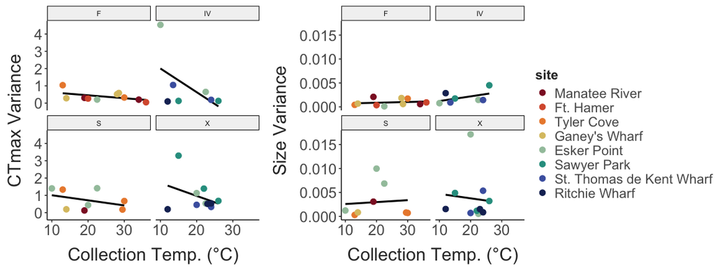

```r
trait_ranges = join_data %>%
  drop_na(clade) %>%
  filter(clade != "A_hudsonica") %>%
  group_by(site, season, clade, collection_temp, collection_salinity, doy, lat) %>%
  summarise(mean_ctmax = mean(ctmax),
            ctmax_range = max(ctmax) - min(ctmax),
            ctmax_var = var(ctmax),
            mean_size = mean(size),
            size_range = max(size) - min(size),
            size_var = var(size)) %>%
  mutate(prop_ctmax_range = ctmax_range / mean_ctmax,
         prop_size_range = size_range / mean_size)

ctmax_range_temp = ggplot(trait_ranges, aes(x = collection_temp, y = ctmax_range)) +
  facet_wrap(clade~.) +
  geom_smooth(method = "lm", colour = "black", se = F) +
  geom_point(aes(colour = site),
             size = 3) +
  scale_colour_manual(values = site_cols) +
  labs(y = "CTmax Range (°C)",
       x = "Collection Temp. (°C)") +
  theme_matt() +
  theme(legend.position = "right")

ctmax_var_temp = ggplot(trait_ranges, aes(x = collection_temp, y = ctmax_var, colour = site)) +
  facet_wrap(clade~.) +
  geom_smooth(method = "lm", colour = "black", se = F) +
  geom_point(aes(colour = site),
             size = 3) +
  scale_colour_manual(values = site_cols) +
  labs(y = "CTmax Variance",
       x = "Collection Temp. (°C)") +
  theme_matt() +
  theme(legend.position = "right")

size_range_temp = ggplot(trait_ranges, aes(x = collection_temp, y = size_range, colour = site)) +
  facet_wrap(clade~.) +
  geom_smooth(method = "lm", colour = "black", se = F) +
  geom_point(aes(colour = site),
             size = 3) +
  scale_colour_manual(values = site_cols) +
  labs(y = "Size Range (mm)",
       x = "Collection Temp. (°C)") +
  theme_matt() +
  theme(legend.position = "right")

size_var_temp = ggplot(trait_ranges, aes(x = collection_temp, y = size_var, colour = site)) +
  facet_wrap(clade~.) +
  geom_smooth(method = "lm", colour = "black", se = F) +
  geom_point(aes(colour = site),
             size = 3) +
  scale_colour_manual(values = site_cols) +
  labs(y = "Size Variance",
       x = "Collection Temp. (°C)") +
  theme_matt() +
  theme(legend.position = "right")

ggarrange(ctmax_var_temp, size_var_temp, common.legend = T, legend = "right")
```

Changes in trait variance may be indicative of phenotypic selection. If selection (as opposed to acclimation) are driving seasonal changes, we may expect to see a reduction in variance in the peak samples relative to the early season samples. Note that early season collection temperatures this year were higher than expected, driven by fairly strong heatwaves across the North Atlantic. As shown in the temperature profiles for each site, the ‘early’ samples were collected just after high temperatures were reached, while ‘peak’ samples were collected after sites had experienced high temperatures for several weeks (generations). As warming tolerances were fairly high throughout this period, we will assume that selection was weak before the early samples. If the early onset of high temperatures filtered out vulnerable genotypes prior to our sampling, the results will be a conservative estimate of the effects of selection on trait variance.

### CTmax variance through the season

If seasonal selection on thermal tolerance were strong, it should remove the least tolerant individuals and narrow CTmax variation within lineages over the season. Within each lineage at each site sampled in two or more seasons (collections with ≥ 5 individuals of the lineage), spread was measured as each individual’s absolute deviation from its collection median (Brown–Forsythe), modelled as |deviation| ~ season + (1 | lineage:site), with early season as the reference.

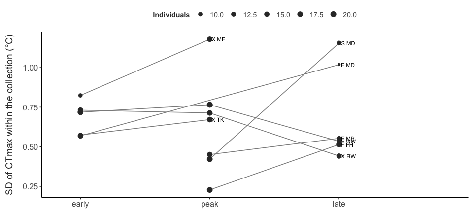

```r
vs <- join_data %>%
  filter(clade %in% tonsa_clades) %>% mutate(lineage = clade) %>%
  group_by(lineage, site_code, season) %>% filter(n() >= 5) %>%
  mutate(absdev = abs(ctmax - median(ctmax))) %>% ungroup() %>%
  group_by(lineage, site_code) %>% filter(n_distinct(season) >= 2) %>% ungroup() %>%
  mutate(season = factor(season, levels = season_order), unit = paste(lineage, site_code))
vs_m <- lme4::lmer(absdev ~ season + (1 | unit), data = vs)
vs_tab <- as_tibble(summary(vs_m)$coefficients, rownames = "term") %>%
  filter(term != "(Intercept)") %>%
  transmute(contrast = sub("season", "", term) %>% paste("vs early"), estimate = Estimate, se = `Std. Error`,
            lo = estimate - 1.96 * se, hi = estimate + 1.96 * se)
vs_sd <- vs %>% group_by(unit, lineage, site_code, season) %>%
  summarise(sd = sd(ctmax), n = n(), .groups = "drop")
write_csv(vs_tab, here("Output", "Output_data", "ctmax_variance_season.csv"))
write_csv(vs_sd, here("Output", "Output_data", "ctmax_sd_by_collection.csv"))
ggplot(vs_sd, aes(x = season, y = sd, group = unit)) +
  geom_line(colour = "grey55") +
  geom_point(aes(size = n), colour = "grey20") +
  geom_text(data = ~ group_by(.x, unit) %>% slice_max(as.integer(season), n = 1), aes(label = unit),
            hjust = -0.15, size = 3) +
  scale_size_continuous(range = c(1.5, 3.5), name = "Individuals") +
  scale_x_discrete(expand = expansion(add = c(0.3, 1))) +
  labs(x = NULL, y = "SD of CTmax within the collection (°C)") +
  theme_matt(base_size = 12)
```

```r
knitr::kable(vs_tab, digits = 3, col.names = c("Contrast", "Change in mean |deviation| (°C)", "SE", "95% lower", "95% upper"),
             caption = sprintf("Change in the spread of CTmax within lineage × site units (%d units, %d individuals), relative to the early season.",
                               n_distinct(vs$unit), nrow(vs)))
```

Change in the spread of CTmax within lineage × site units (8 units, 280 individuals), relative to the early season.

| Contrast | Change in mean \|deviation\| (°C) | SE | 95% lower | 95% upper |
| --- | --- | --- | --- | --- |
| peak vs early | 0.018 | 0.072 | -0.124 | 0.16 |
| late vs early | 0.053 | 0.080 | -0.103 | 0.21 |

CTmax spread did not narrow through the season: relative to early-season collections, the mean absolute deviation changed by +0.02 °C at the peak and +0.05 °C in the late season (95% CIs -0.12 to 0.16 and -0.10 to 0.21). This phenotypic check agrees with the genomic one: there is no sign of strong seasonal selection on thermal tolerance within lineages. It is a weak test, however: spread also reflects assay noise and the mix of acclimation histories within a collection, and immigration can replenish variation.

### Parasites, epibionts and thermal limits

Infected and uninfected individuals are compared within the same collection (same site, date and collection temperature), so differences are not confounded with acclimation temperature. Only collections with at least two positive and two negative individuals are shown.

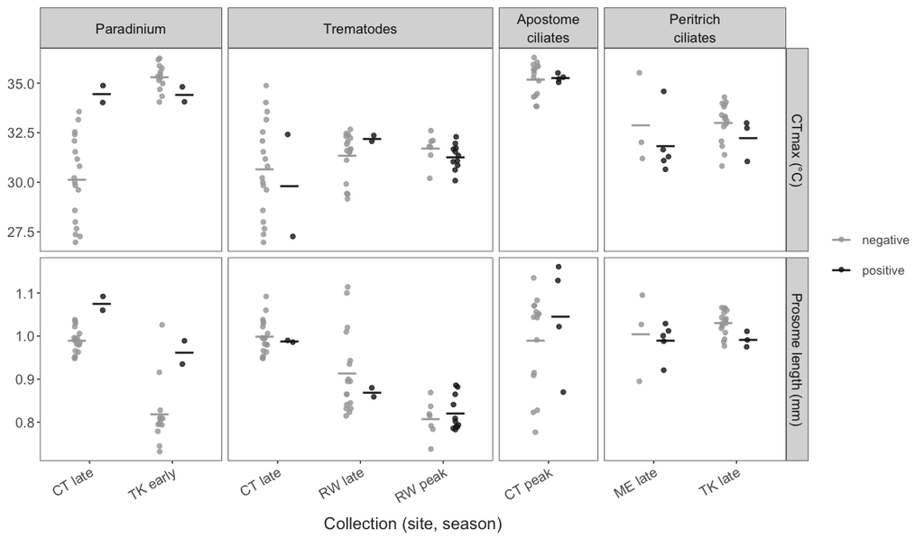

```r
inf_groups <- c(paradinium = "Paradinium", trematode = "Trematodes",
                apostome = "Apostome ciliates", peritrich = "Peritrich ciliates")
inf <- join_data %>%
  select(sample_id, site_code, season, clade, ctmax, size, paste0(names(inf_groups), "_call")) %>%
  pivot_longer(ends_with("_call"), names_to = "group", values_to = "positive",
               names_pattern = "(.*)_call") %>%
  mutate(collection = paste(site_code, season)) %>%
  group_by(group, collection) %>%
  filter(sum(positive) >= 2, sum(!positive) >= 2) %>%
  ungroup() %>%
  mutate(group = factor(inf_groups[group], levels = inf_groups),
         status = factor(if_else(positive, "positive", "negative"), levels = c("negative", "positive")))

if (nrow(inf) == 0) {
  cat("No collection has both infected and uninfected individuals.")
} else {
  inf %>%
    pivot_longer(c(ctmax, size), names_to = "trait") %>%
    mutate(trait = recode(trait, ctmax = "CTmax (°C)", size = "Prosome length (mm)")) %>%
    ggplot(aes(x = collection, y = value, colour = status)) +
    facet_grid(trait ~ group, scales = "free", space = "free_x",
               labeller = labeller(group = label_wrap_gen(12))) +
    geom_point(position = position_jitterdodge(jitter.width = 0.15, dodge.width = 0.6),
               size = 1.8, alpha = 0.8) +
    stat_summary(fun = mean, geom = "point", shape = 95, size = 10,
                 position = position_dodge(width = 0.6)) +
    scale_colour_manual(values = c(negative = "grey65", positive = "grey10")) +
    labs(x = "Collection (site, season)", y = NULL, colour = NULL) +
    theme_matt_facets(base_size = 13) +
    theme(axis.text.x = element_text(angle = 30, hjust = 1))
}
```

```r
infection_fit <- function(var) {
  d <- join_data %>%
    mutate(collection = paste(site_code, season), status = .data[[var]]) %>%
    group_by(collection) %>% filter(any(status), any(!status)) %>% ungroup()
  if (nrow(d) == 0) return(NULL)
  map_dfr(c("ctmax", "size"), function(tr) {
    m <- lme4::lmer(as.formula(paste(tr, "~ status + clade + (1 | collection)")), data = d)
    co <- summary(m)$coefficients["statusTRUE", ]
    tibble(covariate = var, trait = tr, n_collections = n_distinct(d$collection),
           n_positive = sum(d$status), effect = co[["Estimate"]], se = co[["Std. Error"]])
  })
}
inf_tab <- bind_rows(infection_fit("parasite_any"), infection_fit("epibiont_any"))
write_csv(inf_tab, here("Output", "Output_data", "infection_traits.csv"))
inf_tab %>%
  knitr::kable(digits = 3,
               caption = "Effect of carrying a parasite or epibiont on CTmax and size, within collections (trait ~ status + clade + (1 | collection)); only collections with both positive and negative individuals.")
```

Effect of carrying a parasite or epibiont on CTmax and size, within collections (trait ~ status + clade + (1 | collection)); only collections with both positive and negative individuals.

| covariate | trait | n_collections | n_positive | effect | se |
| --- | --- | --- | --- | --- | --- |
| parasite_any | ctmax | 6 | 23 | 0.361 | 0.304 |
| parasite_any | size | 6 | 23 | 0.009 | 0.012 |
| epibiont_any | ctmax | 4 | 13 | -0.233 | 0.312 |
| epibiont_any | size | 4 | 13 | -0.013 | 0.023 |

## 5. Partitioning vulnerability

- **Fixed CTmax:** one value for everyone, the mean of all peak-season individuals.
- **Clade means:** each clade’s peak-season mean CTmax (its mean over all collections when it has < 5 peak-season individuals), weighted by the clade make-up of the site’s peak collection.
- **Clades + acclimation:** CTmax predicted for each clade on each day from the within/between model (population-level, no site random effect): lineage + within-site temperature (the day’s temperature minus the site’s mean collection temperature) + between-site temperature (the site’s long-term MUR mean). The day’s temperature is clamped to the range of collection temperatures at which that lineage was sampled, so acclimation is not extrapolated beyond the data. Same peak-season make-up.

Habitat temperature is the bias-corrected daily MUR SST, 2014–2023 (Section 1), plus 0 or 4 °C for a uniform-warming scenario. Sites are pooled into six regions (Florida: MR, FH; Chesapeake: MD, GW; Connecticut; Maine; Shediac: TK; Miramichi: RW), each site weighted equally; composition and acclimation terms are applied site by site before pooling. Two summaries per region, over August–September (the warmest months, peak abundance, and the period the peak collections represent): the mean warming tolerance of the peak-season population, and the warming tolerance on the warmest August–September day of each year (averaged over years) for the least tolerant lineage making up ≥ 10% of the peak collection. Intervals are 95% ranges from 1,000 bootstrap resamples of individuals (fixed and lineage means) or 1,000 draws of the model’s fixed effects (lineages + acclimation). Individuals’ CTmax was measured against collection-day water temperature, while predictions use MUR SST, which in summer runs cooler than the in-situ collection temperatures at the northern sites (Section 1); the acclimation scenario therefore uses MUR temperatures on a model fitted to in-situ ones.

```r
mur_file <- here("Output", "Output_data", "mur_sst_daily_corrected.csv")
have_mur <- file.exists(mur_file)
if (!have_mur) cat("MUR daily temperatures (Output_data/mur_sst_daily_corrected.csv) are not available.")
```

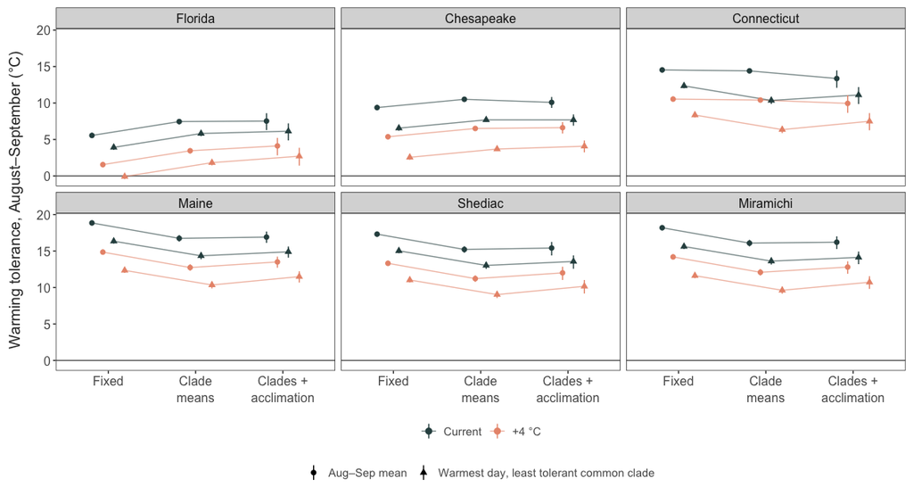

```r
if (have_mur) {
  wt_res %>%
    filter(scenario %in% scen_levels) %>%
    mutate(scenario = factor(scenario, levels = scen_levels),
           warming = factor(if_else(warming == 0, "Current", "+4 °C"), levels = c("Current", "+4 °C"))) %>%
    ggplot(aes(x = scenario, y = est, ymin = lo, ymax = hi, colour = warming, shape = metric,
               group = interaction(warming, metric))) +
    geom_hline(yintercept = 0, colour = "grey40") +
    geom_line(position = position_dodge(width = 0.5), alpha = 0.6) +
    geom_pointrange(position = position_dodge(width = 0.5), size = 0.45) +
    facet_wrap(~ region, nrow = 2) +
    scale_colour_manual(values = c(Current = "darkslategray", `+4 °C` = "darksalmon"), name = NULL) +
    scale_shape_manual(values = c(16, 17), name = NULL) +
    scale_x_discrete(labels = c("Fixed", "Clade\nmeans", "Clades +\nacclimation")) +
    labs(x = NULL, y = "Warming tolerance, August–September (°C)") +
    theme_matt_facets(base_size = 12) +
    theme(legend.position = "bottom", legend.box = "vertical")
}
```

The figure below shows the full distribution of daily warming tolerance in each region behind these summaries, over the whole sampled season (July–November, 2014–2023). Each day is weighted by the lineage make-up of the matching collection: July by the early collection, August–September by the peak collection, October–November by the late collection, using the nearest available collection where one is missing (the Florida sites have no early collection). Point estimates only; current conditions solid, +4 °C pale.

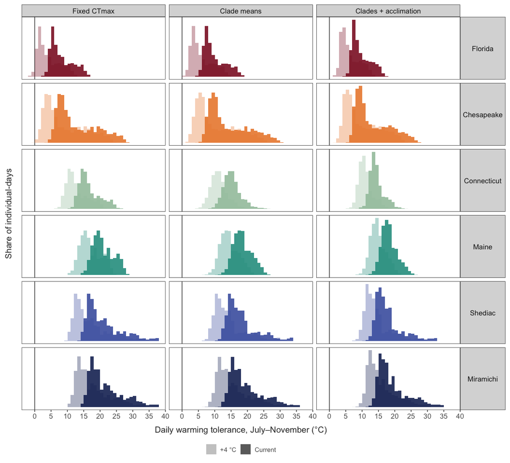

```r
if (have_mur) {
  season_of <- function(m) case_when(m == 7 ~ "early", m %in% 8:9 ~ "peak", m %in% 10:11 ~ "late")
  season_days <- read_csv(mur_file, show_col_types = FALSE) %>%
    filter(site_code %in% site_order, month(date) %in% 7:11) %>%
    transmute(site_code, date, season = season_of(month(date)), temp = sst_c)
  comp_season <- comp %>%
    count(site_code, season, lineage) %>%
    group_by(site_code, season) %>% mutate(p = n / sum(n)) %>% ungroup() %>%
    mutate(across(c(site_code, season, lineage), as.character))
  # nearest available collection when a site lacks one (early -> peak, late -> peak, peak -> late)
  fallback <- list(early = c("early", "peak", "late"), peak = c("peak", "late", "early"),
                   late = c("late", "peak", "early"))
  comp_for <- function(site, sea) {
    for (s2 in fallback[[sea]]) {
      x <- filter(comp_season, site_code == site, season == s2)
      if (nrow(x)) return(x)
    }
  }
  day_comp <- season_days %>% distinct(site_code, season) %>%
    pmap_dfr(function(site_code, season) comp_for(site_code, season) %>% mutate(day_season = season, season = NULL) %>%
               rename(season = day_season))
  bw_hat <- fe[["t_within"]]; bb_hat <- fe[["t_between"]]
  int_hat <- set_names(map_dbl(wt_lin, ~ lin_int(.x)[1]), wt_lin)
  wt_days <- season_days %>%
    inner_join(day_comp, by = c("site_code", "season"), relationship = "many-to-many") %>%
    inner_join(lin_trange, by = "lineage") %>%
    inner_join(site_terms, by = "site_code") %>%
    crossing(warming = c(0, 4)) %>%
    mutate(T = temp + warming, Tc = pmin(pmax(T, tmin), tmax),
           `Fixed CTmax` = ct_fixed[1] - T,
           `Clade means` = map_dbl(lineage, ~ ct_lin[[.x]][1]) - T,
           `Clades + acclimation` = int_hat[lineage] + bw_hat * (Tc - smc) + bb_hat * tb - T) %>%
    pivot_longer(all_of(scen_levels), names_to = "scenario", values_to = "wt") %>%
    group_by(site_code, scenario, warming) %>% mutate(w = p / n_distinct(date)) %>% ungroup() %>%
    mutate(region = factor(wt_region[site_code], levels = region_order)) %>%
    group_by(region, scenario, warming) %>% mutate(w = w / n_distinct(site_code)) %>% ungroup() %>%
    mutate(scenario = factor(scenario, levels = scen_levels),
           warming = factor(if_else(warming == 0, "Current", "+4 °C"), levels = c("+4 °C", "Current")))

  ggplot(wt_days, aes(x = wt, weight = w, fill = region, alpha = warming)) +
    geom_vline(xintercept = 0, colour = "grey30") +
    geom_histogram(binwidth = 1, boundary = 0, position = "identity") +
    facet_grid(region ~ scenario, scales = "free_y") +
    scale_fill_manual(values = region_cols[region_order], guide = "none") +
    scale_alpha_manual(values = c("+4 °C" = 0.35, Current = 0.9), name = NULL) +
    scale_x_continuous(breaks = seq(-5, 40, 5)) +
    labs(x = "Daily warming tolerance, July–November (°C)", y = "Share of individual-days") +
    theme_matt_facets(base_size = 11) +
    theme(axis.text.y = element_blank(), axis.ticks.y = element_blank(),
          strip.text.y = element_text(angle = 0), legend.position = "bottom")
}
```

```r
if (have_mur) {
  wt_range %>%
    transmute(Metric = metric, Scenario = scenario, `Range among regions (°C)` = round(range, 1),
              `Change vs fixed CTmax` = if_else(scenario == "Fixed CTmax", "–", sprintf("%+.0f%%", change))) %>%
    knitr::kable(caption = "Spread of warming tolerance among regions under current conditions. The last scenario uses each site's lineage make-up across all collections instead of the peak collection.")
}
```

Spread of warming tolerance among regions under current conditions. The last scenario uses each site’s lineage make-up across all collections instead of the peak collection.

| Metric | Scenario | Range among regions (°C) | Change vs fixed CTmax |
| --- | --- | --- | --- |
| Aug–Sep mean | Fixed CTmax | 13.3 | – |
| Aug–Sep mean | Clade means | 9.3 | -30% |
| Aug–Sep mean | Clades + acclimation | 9.4 | -29% |
| Aug–Sep mean | Clades + acclimation (annual make-up) | 9.2 | -31% |
| Warmest day, least tolerant common clade | Fixed CTmax | 12.4 | – |
| Warmest day, least tolerant common clade | Clade means | 8.5 | -31% |
| Warmest day, least tolerant common clade | Clades + acclimation | 8.8 | -30% |
| Warmest day, least tolerant common clade | Clades + acclimation (annual make-up) | 8.4 | -32% |

Relative to a single CTmax, clade means change the spread of peak-season warming tolerance among regions by -30%, and clades with acclimation by -29% (warmest-day metric: -31% and -30%). With +4 °C, the lowest warming tolerance on the warmest day is at Florida under Clade means (1.8 °C); Florida under Clades + acclimation (2.7 °C); Florida under Fixed CTmax (-0.1 °C).

These are illustrations, not forecasts: they assume composition and the acclimation response stay as observed, warming is uniform through the season, and CTmax is the relevant limit.

## 6. Manuscript figures

Main-text figures for the merged manuscript, assembled from the analyses above (saved as `Output/Figures/ms-fig<N>-1.png` / `.pdf`).

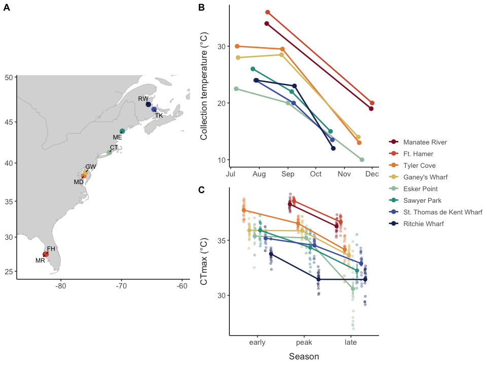

```r
# Figure 1: sites, collection temperatures, CTmax by season
coords <- site_data %>% filter(site_code %in% site_order) %>% distinct(site, site_code, long, lat)
m1_map <- map_data("world") %>%
  filter(region %in% c("USA", "Canada")) %>%
  ggplot() +
  geom_polygon(aes(x = long, y = lat, group = group), fill = "grey85", colour = "grey70", linewidth = 0.2) +
  geom_point(data = coords, aes(x = long, y = lat, colour = site), size = 3) +
  ggrepel::geom_text_repel(data = coords, aes(x = long, y = lat, label = site_code), size = 3.2,
                           min.segment.length = 0, box.padding = 0.3, seed = 1) +
  coord_map(xlim = c(-86, -60), ylim = c(25, 49)) +
  scale_colour_manual(values = site_cols, guide = "none") +
  labs(x = NULL, y = NULL) +
  theme_matt(base_size = 11)
m1_temp <- site_temps %>%
  mutate(site = factor(site, levels = names(site_cols))) %>%
  ggplot(aes(x = as.Date(doy - 1, origin = "2023-01-01"), y = collection_temp, colour = site)) +
  geom_line(linewidth = 1) +
  geom_point(size = 2.5) +
  scale_colour_manual(values = site_cols, name = NULL) +
  scale_x_date(date_labels = "%b", date_breaks = "1 month") +
  labs(x = NULL, y = "Collection temperature (°C)") +
  theme_matt(base_size = 11)
m1_ctmax <- join_data %>%
  mutate(season = factor(season, levels = season_order), site = factor(site, levels = names(site_cols))) %>%
  ggplot(aes(x = season, y = ctmax, colour = site, group = site)) +
  geom_point(position = position_jitterdodge(jitter.width = 0.12, dodge.width = 0.7, seed = 1),
             alpha = 0.35, size = 1.2) +
  stat_summary(fun = mean, geom = "line", position = position_dodge(width = 0.7), linewidth = 0.9) +
  stat_summary(fun.data = mean_se, geom = "pointrange", position = position_dodge(width = 0.7), size = 0.35) +
  scale_colour_manual(values = site_cols, name = NULL) +
  labs(x = "Season", y = "CTmax (°C)") +
  theme_matt(base_size = 11)
ggarrange(m1_map, ggarrange(m1_temp, m1_ctmax, ncol = 1, labels = c("B", "C"), common.legend = TRUE, legend = "right"),
          nrow = 1, widths = c(0.8, 1.2), labels = c("A", ""))
```

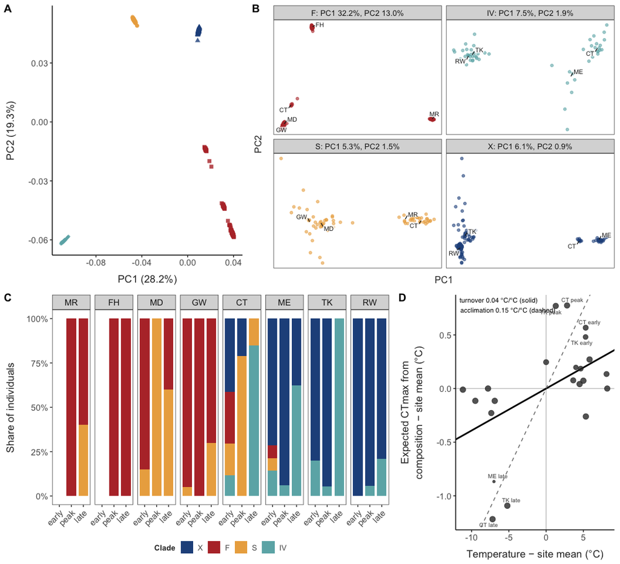

```r
# Figure 2: genome-wide structure (PCA), clade composition, and the CTmax shift from lineage turnover
# Supplementary: genome-wide PCA of all individuals, and PCAs within each clade
m3_all <- ggplot(pca_all, aes(x = PC1, y = PC2, colour = clade, shape = clade)) +
  geom_point(size = 2, alpha = 0.8) +
  scale_colour_manual(values = clade_cols[tonsa_clades], name = "Clade") +
  scale_shape_manual(values = clade_shapes[tonsa_clades], name = "Clade") +
  labs(x = sprintf("PC1 (%.1f%%)", ve[1]), y = sprintf("PC2 (%.1f%%)", ve[2])) +
  theme_matt(base_size = 11) +
  theme(legend.position = "bottom")
wpc <- wpca %>%
  mutate(clade = factor(str_extract(panel, "^[A-Z]+"), levels = tonsa_clades),
         lab = sprintf("%s: PC1 %s, PC2 %s", clade, str_extract(panel, "(?<=PC1 )[0-9.]+%"),
                       str_extract(panel, "(?<=PC2 )[0-9.]+%")))
wpc_lab <- wpc %>% group_by(lab, clade, site) %>% summarise(PC1 = median(PC1), PC2 = median(PC2), n = n(), .groups = "drop") %>%
  filter(n >= 3)
m3_within <- ggplot(wpc, aes(x = PC1, y = PC2, colour = clade)) +
  geom_point(size = 1.4, alpha = 0.6) +
  ggrepel::geom_label_repel(data = wpc_lab, aes(label = site), colour = "grey15", size = 2.8, label.size = 0,
                            label.padding = unit(0.08, "lines"), fill = alpha("white", 0.75),
                            min.segment.length = 0, box.padding = 0.15, seed = 1) +
  facet_wrap(~ lab, scales = "free", nrow = 2) +
  scale_colour_manual(values = clade_cols[tonsa_clades], guide = "none") +
  labs(x = "PC1", y = "PC2") +
  theme_matt_facets(base_size = 10) +
  theme(axis.text = element_blank(), axis.ticks = element_blank())
clade_comp <- seq_data %>%
  filter(clade %in% tonsa_clades, !sample_id %in% c("MR_peak_2_04", "MR_peak_2_05")) %>%
  mutate(clade = factor(clade, levels = tonsa_clades), season = factor(season, levels = season_order),
         site_code = factor(site_code, levels = site_order))
m2_comp <- ggplot(clade_comp, aes(x = season, fill = clade)) +
  geom_bar(position = "fill", width = 0.8) +
  facet_wrap(~ site_code, nrow = 1) +
  scale_fill_manual(values = clade_cols[tonsa_clades], name = "Clade") +
  scale_x_discrete(drop = FALSE) +
  scale_y_continuous(labels = scales::percent) +
  labs(x = NULL, y = "Share of individuals") +
  theme_matt_facets(base_size = 11) +
  theme(axis.text.x = element_text(angle = 45, hjust = 1), legend.position = "bottom")
# turnover: expected CTmax from composition vs collection temperature, both relative to the site mean
turn_dev <- ce_obs %>% group_by(site_code) %>% filter(n() > 1) %>%
  mutate(d_ct = exp_ctmax - weighted.mean(exp_ctmax, n), d_t = temp - weighted.mean(temp, n)) %>% ungroup()
m2_turn <- ggplot(turn_dev, aes(x = d_t, y = d_ct)) +
  geom_hline(yintercept = 0, colour = "grey80") + geom_vline(xintercept = 0, colour = "grey80") +
  geom_abline(slope = slope_obs, intercept = 0, linewidth = 1) +
  geom_abline(slope = acc_slope, intercept = 0, linetype = "dashed", colour = "grey50") +
  geom_point(aes(size = n), colour = "grey20", alpha = 0.8) +
  ggrepel::geom_text_repel(data = ~ filter(.x, abs(d_ct) > 0.35), aes(label = paste(site_code, season)),
                           size = 2.6, colour = "grey30", seed = 1, min.segment.length = 0.2) +
  scale_size_continuous(range = c(1.2, 3), guide = "none") +
  annotate("text", x = -Inf, y = Inf, hjust = -0.05, vjust = 1.2, size = 3,
           label = sprintf("turnover %.2f °C/°C (solid)\nacclimation %.2f °C/°C (dashed)", slope_obs, acc_slope)) +
  labs(x = "Temperature − site mean (°C)", y = "Expected CTmax from\ncomposition − site mean (°C)") +
  theme_matt(base_size = 11)
m3_all <- m3_all + theme(legend.position = "none")
ggarrange(ggarrange(m3_all, m3_within, nrow = 1, widths = c(0.8, 1.2), labels = c("A", "B")),
          ggarrange(m2_comp, m2_turn, nrow = 1, widths = c(1.75, 1), labels = c("C", "D")),
          ncol = 1, heights = c(1, 0.95))
```

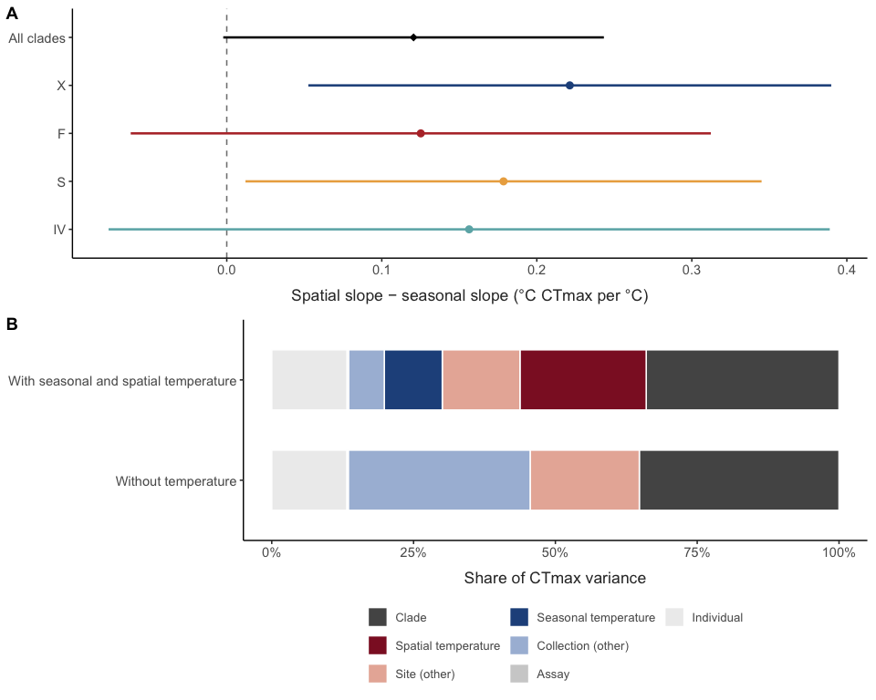

```r
# Figure 3: phenotype - CTmax differs more per degree between sites (space) than through the season
ci_tab <- function(m, terms) {
  b <- lme4::fixef(m); se <- sqrt(diag(as.matrix(vcov(m))))
  tibble(term = terms, est = b[terms], lo = b[terms] - 1.96 * se[terms], hi = b[terms] + 1.96 * se[terms])
}
diff_dat <- wb_diff %>% filter(split == "Season-mean split") %>%
  mutate(group = factor(group, levels = rev(c("All clades", tonsa_clades))), all = group == "All clades")
m3_slopes <- ggplot(diff_dat, aes(x = diff, y = group, colour = group, shape = all)) +
  geom_vline(xintercept = 0, colour = "grey50", linetype = "dashed") +
  geom_pointrange(aes(xmin = lo, xmax = hi), size = 0.6, linewidth = 0.9) +
  scale_colour_manual(values = c(clade_cols[tonsa_clades], `All clades` = "black"), guide = "none") +
  scale_shape_manual(values = c(`FALSE` = 16, `TRUE` = 18), guide = "none") +
  labs(x = "Spatial slope − seasonal slope (°C CTmax per °C)", y = NULL) +
  theme_matt(base_size = 11)
m4_ctmax <- ggplot(filter(vp_tab, share > 0), aes(x = model, y = share, fill = component)) +
  geom_col(width = 0.6, colour = "white") +
  coord_flip() +
  scale_y_continuous(labels = scales::percent) +
  scale_fill_manual(values = vp_cols, name = NULL) +
  guides(fill = guide_legend(nrow = 3)) +
  labs(x = NULL, y = "Share of CTmax variance") +
  theme_matt(base_size = 11) +
  theme(legend.position = "bottom")
ggarrange(m3_slopes, m4_ctmax, ncol = 1, heights = c(0.8, 1), labels = c("A", "B"))
```

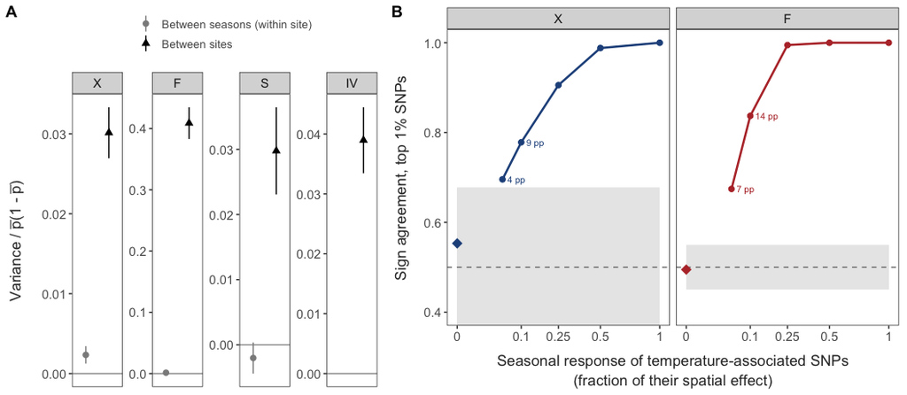

```r
# Figure 4: genome - variation lies between sites, not seasons; seasonal change does not echo spatial temperature associations
# F spans divergent populations (Florida vs Chesapeake), so its between-site variance is ~10x the
# other clades': one panel per clade, each on its own scale
m4_freq_n <- ggplot(filter(vp_freq, !is.na(value)) %>% mutate(group = factor(group, levels = tonsa_clades)),
                    aes(x = component, y = value, shape = component, colour = component)) +
  geom_hline(yintercept = 0, colour = "grey60") +
  geom_pointrange(aes(ymin = lo, ymax = hi), size = 0.5) +
  facet_wrap(~ group, nrow = 1, scales = "free_y") +
  scale_x_discrete(labels = NULL, breaks = NULL) +
  scale_colour_manual(values = c(`Between sites` = "black", `Between seasons (within site)` = "grey55"), name = NULL) +
  scale_shape_manual(values = c(16, 17), name = NULL) +
  labs(x = NULL, y = expression("Variance / " * bar(p) * "(1 - " * bar(p) * ")")) +
  guides(colour = guide_legend(nrow = 2), shape = guide_legend(nrow = 2)) +
  theme_matt_facets(base_size = 11) +
  theme(legend.position = "bottom")
# concordance sensitivity: injected seasonal response (fraction of the spatial slope, top 1% SNPs) vs sign agreement
conc_null <- conc %>% filter(snp_set == "all chr.", null == "seasonal", snps_used == "unlinked") %>%
  mutate(clade = as.character(clade)) %>% filter(clade %in% c("X", "F")) %>%
  group_by(clade) %>% summarise(lo = min(conc_top1[!observed]), hi = max(conc_top1[!observed]),
                                obs = conc_top1[observed][1], .groups = "drop")
conc_inj <- map_dfr(c("X", "F"), ~ read_tsv(cx("results", "18_power", paste0(.x, ".concordance.tsv")),
                                           col_types = cols(clade = "c", .default = col_guess()))) %>%
  filter(frac == 0.01) %>% select(clade, lambda, conc_top1, seasonal_logit_change) %>%
  bind_rows(transmute(conc_null, clade, lambda = 0, conc_top1 = obs, seasonal_logit_change = 0)) %>%
  arrange(clade, lambda)
conc_plot_dat <- conc_inj %>% mutate(clade = factor(clade, levels = c("X", "F")))
conc_null <- conc_null %>% mutate(clade = factor(clade, levels = c("X", "F")))
m4_conc <- ggplot(conc_plot_dat, aes(x = lambda, y = conc_top1, colour = clade)) +
  geom_rect(data = conc_null, aes(xmin = 0, xmax = 1, ymin = lo, ymax = hi), inherit.aes = FALSE,
            fill = "grey85", alpha = 0.6) +
  geom_hline(yintercept = 0.5, colour = "grey50", linetype = "dashed") +
  geom_line(data = ~ filter(.x, lambda > 0), linewidth = 0.9) +
  geom_point(data = ~ filter(.x, lambda > 0), size = 2) +
  geom_point(data = ~ filter(.x, lambda == 0), size = 4, shape = 18) +
  ggrepel::geom_text_repel(data = ~ filter(.x, lambda %in% c(0.05, 0.1)),
                           aes(label = sprintf("%.0f pp", 100 * (plogis(seasonal_logit_change) - 0.5))),
                           size = 2.8, show.legend = FALSE, seed = 1, nudge_x = 0.05) +
  facet_wrap(~ clade, nrow = 1) +
  scale_colour_manual(values = clade_cols[c("X", "F")], guide = "none") +
  scale_x_sqrt(breaks = c(0, 0.1, 0.25, 0.5, 1), labels = c("0", "0.1", "0.25", "0.5", "1")) +
  coord_cartesian(ylim = c(0.4, 1)) +
  labs(x = "Seasonal response of temperature-associated SNPs\n(fraction of their spatial effect)",
       y = "Sign agreement, top 1% SNPs") +
  theme_matt_facets(base_size = 11)
ggarrange(m4_freq_n + theme(legend.position = "top", legend.direction = "vertical", legend.title = element_blank()),
          m4_conc, nrow = 1, widths = c(0.85, 1.15), labels = c("A", "B"))
```

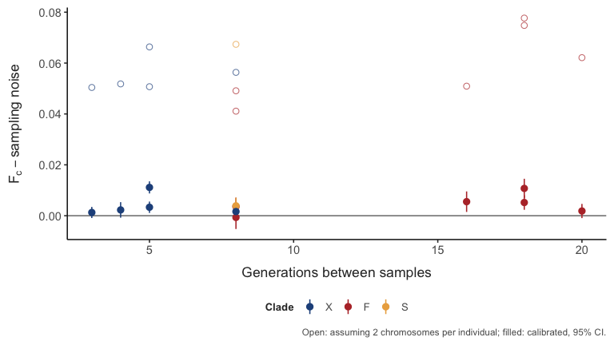

```r
# Supplementary: seasonal allele-frequency change against the drift expectation
m4_drift <- temporal %>%
  mutate(uncal = Fc - sampling_2n, clade = factor(as.character(clade), levels = tonsa_clades)) %>%
  ggplot(aes(x = gens, colour = clade)) +
  geom_hline(yintercept = 0, colour = "grey50") +
  geom_point(aes(y = uncal), shape = 1, size = 2.3, alpha = 0.7) +
  geom_pointrange(aes(y = excess, ymin = excess - 1.96 * se, ymax = excess + 1.96 * se), size = 0.45) +
  scale_colour_manual(values = clade_cols[tonsa_clades], name = "Clade", drop = TRUE) +
  labs(x = "Generations between samples", y = expression(F[c] - "sampling noise"),
       caption = "Open: assuming 2 chromosomes per individual; filled: calibrated, 95% CI.") +
  theme_matt(base_size = 11) +
  theme(legend.position = "bottom")
m4_drift
```

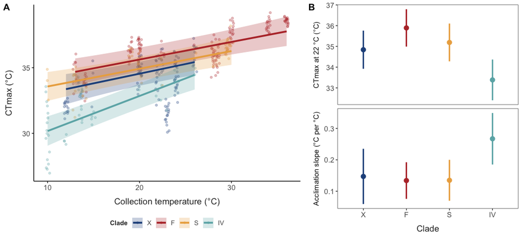

```r
# Figure 5: clade differences in CTmax and acclimation, from ctmax ~ clade * temperature (+ site, replicate, tube)
t_off <- mean(filtered_data$collection_temp - filtered_data$temp_cent)
ci_cols <- function(d) c(intersect(c("lower.CL", "asymp.LCL"), names(d))[1], intersect(c("upper.CL", "asymp.UCL"), names(d))[1])
clade_rng <- filtered_data %>% filter(clade %in% tonsa_clades) %>%
  group_by(clade) %>% summarise(lo = min(temp_cent), hi = max(temp_cent), .groups = "drop")
pred5 <- pmap_dfr(clade_rng, function(clade, lo, hi) {
  as_tibble(summary(emmeans::emmeans(ctmax.model, ~ clade | temp_cent,
                                     at = list(clade = clade, temp_cent = seq(lo, hi, length.out = 30)))))
}) %>% mutate(clade = factor(as.character(clade), levels = tonsa_clades), temp = temp_cent + t_off)
cc <- ci_cols(pred5)
pt5 <- filtered_data %>% filter(clade %in% tonsa_clades) %>% mutate(clade = factor(clade, levels = tonsa_clades))
m5a <- ggplot() +
  geom_point(data = pt5, aes(x = collection_temp, y = ctmax, colour = clade), alpha = 0.3, size = 1.3,
             position = position_jitter(width = 0.25, height = 0, seed = 1)) +
  geom_ribbon(data = pred5, aes(x = temp, ymin = .data[[cc[1]]], ymax = .data[[cc[2]]], fill = clade), alpha = 0.25) +
  geom_line(data = pred5, aes(x = temp, y = emmean, colour = clade), linewidth = 1.3) +
  scale_colour_manual(values = clade_cols[tonsa_clades], name = "Clade") +
  scale_fill_manual(values = clade_cols[tonsa_clades], name = "Clade") +
  labs(x = "Collection temperature (°C)", y = "CTmax (°C)") +
  theme_matt(base_size = 11) +
  theme(legend.position = "bottom")
mm <- as_tibble(summary(emmeans::emmeans(ctmax.model, ~ clade), infer = TRUE))
tr <- as_tibble(summary(emmeans::emtrends(ctmax.model, ~ clade, var = "temp_cent"), infer = TRUE))
m5b <- bind_rows(
  transmute(mm, clade, est = emmean, lo = .data[[ci_cols(mm)[1]]], hi = .data[[ci_cols(mm)[2]]],
            panel = sprintf("CTmax at %.0f °C (°C)", t_off)),
  transmute(tr, clade, est = temp_cent.trend, lo = .data[[ci_cols(tr)[1]]], hi = .data[[ci_cols(tr)[2]]],
            panel = "Acclimation slope (°C per °C)")) %>%
  mutate(clade = factor(as.character(clade), levels = tonsa_clades), panel = factor(panel, levels = unique(panel))) %>%
  ggplot(aes(x = clade, y = est, ymin = lo, ymax = hi, colour = clade)) +
  geom_pointrange(size = 0.6, linewidth = 1) +
  facet_wrap(~ panel, scales = "free_y", ncol = 1, strip.position = "left") +
  scale_colour_manual(values = clade_cols[tonsa_clades], guide = "none") +
  labs(x = "Clade", y = NULL) +
  theme_matt_facets(base_size = 11) +
  theme(strip.placement = "outside", strip.background = element_blank())
ggarrange(m5a, m5b, nrow = 1, widths = c(1.4, 1), labels = c("A", "B"))
```

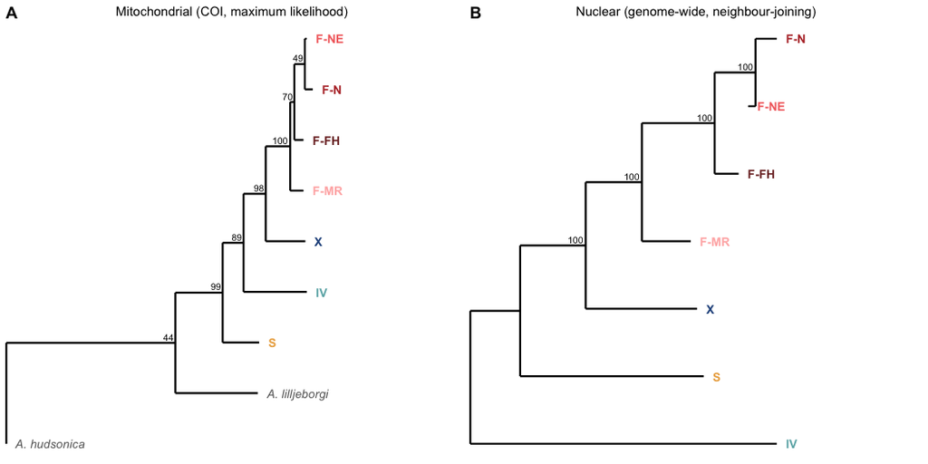

```r
# Supplementary: lineage trees, mitochondrial (COI ML) and nuclear (NJ on net distances)
tip_cols <- c(lin_col, `A. hudsonica` = "grey40", `A. lilljeborgi` = "grey40")
m2_coi <- gg_tree(coi_red, "Mitochondrial (COI, maximum likelihood)", tip_cols)
m2_nuc <- gg_tree(nuc_tr, "Nuclear (genome-wide, neighbour-joining)", tip_cols)
ggarrange(m2_coi, m2_nuc, nrow = 1, labels = c("A", "B"))
```

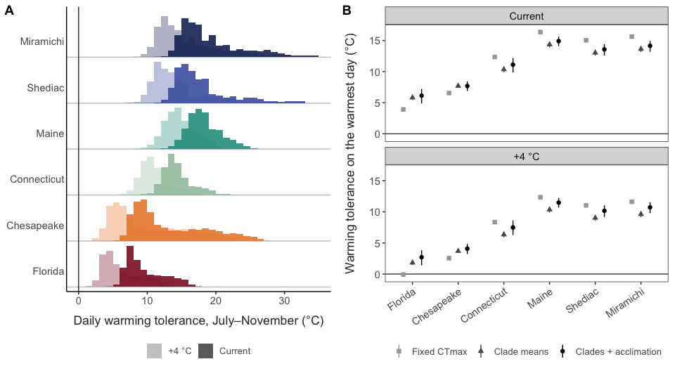

```r
# Figure 6: warming tolerance with lineages + acclimation (distribution), and the warmest day under each scenario
if (have_mur) {
  hist6 <- wt_days %>%
    filter(scenario == "Clades + acclimation") %>%
    mutate(bin = floor(wt)) %>%
    group_by(region, warming, bin) %>% summarise(w = sum(w), .groups = "drop") %>%
    group_by(region) %>% mutate(h = 0.9 * w / max(w)) %>% ungroup() %>%
    mutate(y0 = as.integer(region) - 1)
  m6_hist <- ggplot(hist6) +
    geom_hline(aes(yintercept = y0), data = distinct(hist6, region, y0), colour = "grey80") +
    geom_vline(xintercept = 0, colour = "grey30") +
    geom_rect(aes(xmin = bin, xmax = bin + 1, ymin = y0, ymax = y0 + h, fill = region, alpha = warming)) +
    scale_fill_manual(values = region_cols[region_order], guide = "none") +
    scale_alpha_manual(values = c(`+4 °C` = 0.35, Current = 0.9), name = NULL) +
    scale_y_continuous(breaks = seq_along(region_order) - 1 + 0.35, labels = region_order, expand = expansion(add = c(0.1, 0.2))) +
    labs(x = "Daily warming tolerance, July–November (°C)", y = NULL) +
    theme_matt(base_size = 11) +
    theme(legend.position = "bottom", axis.ticks.y = element_blank())
  m6_hot <- wt_res %>%
    filter(scenario %in% scen_levels, metric != "Aug–Sep mean") %>%
    mutate(scenario = factor(scenario, levels = scen_levels),
           warming = factor(if_else(warming == 0, "Current", "+4 °C"), levels = c("Current", "+4 °C"))) %>%
    ggplot(aes(x = region, y = est, ymin = lo, ymax = hi, colour = scenario, shape = scenario)) +
    geom_hline(yintercept = 0, colour = "grey30") +
    geom_pointrange(position = position_dodge(width = 0.6), size = 0.4) +
    facet_wrap(~ warming, ncol = 1) +
    scale_colour_manual(values = c(`Fixed CTmax` = "grey65", `Clade means` = "grey35", `Clades + acclimation` = "black"),
                        name = NULL) +
    scale_shape_manual(values = c(`Fixed CTmax` = 15, `Clade means` = 17, `Clades + acclimation` = 16), name = NULL) +
    labs(x = NULL, y = "Warming tolerance on the warmest day (°C)") +
    theme_matt_facets(base_size = 11) +
    theme(legend.position = "bottom", axis.text.x = element_text(angle = 35, hjust = 1))
  ggarrange(m6_hist, m6_hot, nrow = 1, widths = c(1, 1), labels = c("A", "B"))
}
```